# Przygotowanie i walidacja danych

# Wstęp

**Pytanie badawcze: Czy kraje europejskie o wysokim PKB i dużym udziale gospodarki leśnej w PKB mają wysoki poziom lesistości?**

*Hipoteza badawcza: Kraje europejskie o wysokim PKB i dużym udziale gospodarki leśnej w PKB mają wysoki poziom lesistości.*

**Pytanie badawcze: Czy istnieje zależność między wielkością powierzchni lądowej krajów europejskich a poziomem lesistości oraz udziałem gospodarki leśnej w PKB?**

*Hipoteza badawcza: Kraje europejskie o dużej powierzchni lądowej mają większy poziom lesistości i udział gospodarki leśnej w PKB.*

## Biblioteki

```r
library(dplyr)
library(ggplot2)
library(tidyr)
library(corrplot)
library(GGally)
library(VIM)
library(rcompanion)
```

## Funkcje

Funkcja **convert_to_long** przekształca tabelę, która zawiera lata w wielu kolumnach na tabelę z kolumną **Year** i odpowiednią kolumną z wartością.

```r
convert_to_long <- function(df, value_col = "value") {
  # Argumenty:
  # df - zbiór danych typu data.frame
  # value_col - nazwa nowej zmiennej/kolumny, do której trafią wartości po zmianie układu danych
  # jeśli nie podano, domyślnie przyjmowana jest nazwa "value"

  # wyszukiwanie nazw kolumn zawierających lata
  year_cols <- grep(
    "19[0-9]{2}|20[0-9]{2}",  # lata od 1900 do 2099
    names(df),              # wektor nazw kolumn zbioru df
    value = TRUE            # zwróć nazwy kolumn, a nie ich indeksy
  )

  # jeśli wektor year_cols jest pusty, funkcja przerywa działanie i wyświetla błąd
  if (length(year_cols) == 0) stop("Nie znaleziono kolumn lat w tabeli.")

  # konwersja wszystkich kolumn z latami do typu numerycznego
  df[year_cols] <- lapply(
    df[year_cols],          # podzbiór danych: tylko kolumny z latami
    function(x)             # funkcja działająca na każdej kolumnie
      as.numeric(           # konwersja do typu numerycznego
        as.character(x)     # najpierw konwersja do character
      )
  )

  # transformacja danych do układu prostokątnego danych
  df_long <- df %>%
    # zamienia wybrane kolumny w wiersze, tworząc kolumnę 'Year'
    tidyr::pivot_longer( # oraz kolumnę z odpowiadającymi im wartościami.
      cols = all_of(year_cols),  # kolumny, które mają zostać "spłaszczone"
      names_to = "Year",         # nazwa nowej kolumny z latami
      values_to = value_col     # nazwa kolumny z wartościami (argument funkcji)
    ) %>%
    dplyr::mutate(
      Year = stringr::str_extract(
        Year,                    # kolumna Year (pochodzi z nazw kolumn)
        "19[0-9]{2}|20[0-9]{2}"   # wydobycie samego roku z nazwy kolumny
      ),
      Year = as.numeric(Year)    # konwersja kolumny Year do typu numerycznego
    )

  return(df_long) # zwrócenie przekształconego zbioru danych
}
```

Funkcja **normal_dstr_check** rysuje histogram, wykres kwantyl-kwantyl i wykonuje test Shaphiro-Wilka, w celu sprawdzenia czy nasza zmienna ma rozkład normalny.

```r
normal_dstr_check <- function(df, column_name, bins = 30, custom_title, custom_xlab) {
  # Argumenty:
  # df - zbiór danych typu data.frame
  # column_name - zmienna poddana analizie
  # bins - argument histogramu odpowiedzialny za liczbę przedziałów
  # jeśli nie podano, domyślnie przyjmowana jest liczba 30
  # custom_title - element tytułu
  # custom_xlab - etykieta osi X

  # if() - instrukcja warunkowa sprawdzająca spełnienie warunku
  # %in% - sprawdza, czy element znajduje się w danym zbiorze
  # colnames() - zwraca nazwy kolumn data.frame
  if (!column_name %in% colnames(df)) { # Sprawdzenie czy kolumna istnieje
    stop("Kolumna nie istnieje w data frame.") # przerywa działanie funkcji i zgłasza błąd
  }

  data <- df[[column_name]] # [[ ]] - wyodrębnia pojedynczą kolumnę z data.frame
  data <- na.omit(data) # na.omit() - usuwa obserwacje zawierające wartości NA

  # ggplot() - inicjalizuje obiekt wykresu w pakiecie ggplot2
  # aes() - definiuje estetyki wykresu
  p1 <- ggplot(data.frame(x = data), aes(x = x)) +

    # geom_histogram() - rysuje histogram rozkładu zmiennej
    geom_histogram(bins = bins, fill = "forestgreen", color = "black", na.rm = TRUE) +

    labs( # labs() - dodaje tytuł i opisy osi wykresu
      title = paste("Histogram", custom_title), # łączy tekst z nazwą zmiennej
      x = custom_xlab, y = "Liczebność"
    ) +
    theme_minimal() + # ustawia minimalistyczny motyw wykresu
    theme( # theme() - modyfikacja elementów motywu
      plot.title = element_text(hjust = 0.5) # hjust = 0.5 oznacza wyśrodkowanie tytułu
    )

  print(p1)

  p2 <- ggplot(data.frame(sample = data), aes(sample = sample)) +
    stat_qq() + # stat_qq() - tworzy punkty wykresu kwantyl-kwantyl
    stat_qq_line(color = "red") + # dodaje linię odniesienia dla rozkładu normalnego

    labs( # labs() - dodaje tytuł i opisy osi
      title = paste("Wykres kwantyl-kwantyl", custom_title),
      x = "Teoretyczne kwantyle",
      y = "Kwantyle empiryczne"
    ) +

    theme_minimal() + # theme_minimal() - minimalistyczny motyw wykresu
    theme( # theme() - modyfikacja elementów motywu
      plot.title = element_text(hjust = 0.5) # hjust = 0.5 oznacza wyśrodkowanie tytułu
    )

  print(p2)

  # shapiro.test() - przeprowadza test Shapiro-Wilka normalności rozkładu
  shapiro_result <- shapiro.test(data)

  return(shapiro_result)
}
```

Funkcja **normal_log_dstr_check** rysuje histogram, wykres kwantyl-kwantyl i wykonuje test Shaphiro-Wilka dla zlogarytmowanej zmiennej, w celu sprawdzenia, czy ma ona rozkład log-normalny.

```r
normal_log_dstr_check <- function(df, column_name, bins = 30, custom_title, custom_xlab) {
  # Argumenty:
  # df - zbiór danych typu data.frame
  # column_name - zmienna poddana analizie
  # bins - argument histogramu odpowiedzialny za liczbę przedziałów
  # jeśli nie podano, domyślnie przyjmowana jest liczba 30
  # custom_title - element tytułu
  # custom_xlab - etykieta osi X

  # if() - instrukcja warunkowa sprawdzająca warunek
  # %in% - sprawdza, czy element znajduje się w danym zbiorze
  # colnames() - zwraca nazwy kolumn data.frame
  # stop() - przerywa działanie funkcji i zgłasza błąd
  if (!column_name %in% colnames(df)) { # Sprawdzenie czy kolumna istnieje
    stop("Kolumna nie istnieje w data frame.")
  }

  data <- df[[column_name]] # [[ ]] - wyodrębnia pojedynczą kolumnę z data.frame
  data <- na.omit(data) # na.omit() - usuwa obserwacje zawierające wartości NA

  data <- data[data > 0] # Filtracja wartości dodatnich (log nie działa dla <= 0)

  # length() - sprawdza liczbę elementów w wektorze
  if (length(data) < 3) stop("Za mało danych po usunięciu wartości niedodatnich.")

  log_data <- log(data) # log() - oblicza logarytm naturalny każdej wartości

  # data.frame() - tworzy ramkę danych dla ggplot
  # ggplot() - inicjalizuje obiekt wykresu w pakiecie ggplot2
  # aes() - definiuje estetyki wykresu (mapowanie zmiennych)
  p1 <- ggplot(data.frame(x = log_data), aes(x = x)) +
    # geom_histogram() - rysuje histogram rozkładu zmiennej
    geom_histogram(bins = bins, fill = "forestgreen", color = "black", na.rm = TRUE) +

    labs( # labs() - dodaje tytuł i opisy osi wykresu
      title = paste("Histogram", custom_title, "po logarytmizacji"), # łączy tekst z nazwą zmiennej
      x = paste("log(", custom_xlab, ")"),
      y = "Liczebność"
    ) +

    theme_minimal() + # theme_minimal() - ustawia minimalistyczny motyw wykresu
    theme( # theme() - modyfikacja elementów motywu
      plot.title = element_text(hjust = 0.5) # hjust = 0.5 oznacza wyśrodkowanie tytułu
    )

  print(p1)

  p2 <- ggplot(data.frame(sample = log_data), aes(sample = sample)) +
    stat_qq() + # stat_qq() - tworzy punkty wykresu kwantyl-kwantyl
    stat_qq_line(color = "red") + # dodaje linię odniesienia dla rozkładu normalnego

    labs( # labs() - dodaje tytuł i opisy osi
      title = paste("Wykres kwantyl-kwantyl", custom_title, "po logarytmizacji"),
      x = "Teoretyczne kwantyle",
      y = "Kwantyle empiryczne"
    ) +

    theme_minimal() + # theme_minimal() - minimalistyczny motyw wykresu
    theme( # theme() - modyfikacja elementów motywu
      plot.title = element_text(hjust = 0.5) # hjust = 0.5 oznacza wyśrodkowanie tytułu
    )

  print(p2)

  # shapiro.test() - przeprowadza test Shapiro-Wilka normalności rozkładu dla log(X)
  shapiro_result <- shapiro.test(log_data)

  return(shapiro_result)
}
```

Funkcja **anova_table** przedstawia analizę wariancji (ANOVA) dla wszystkich zmiennych ilościowych w zbiorze danych względem wybranej zmiennej jakościowej. Dodatkowo określa, które zmienne ilościowe różnią się istotnie statystycznie między grupami.

```r
anova_table <- function(df, cat_var, alpha = 0.05) {
  # Argumenty:
  # df - zbiór danych typu data.frame
  # cat_var - nazwa zmiennej jakościowej, na której wykonujemy test ANOVA
  # alpha - poziom istotności

  # if() - instrukcja warunkowa sprawdzająca spełnienie warunku
  # %in% - sprawdza, czy element znajduje się w wektorze
  # names() - zwraca nazwy kolumn data.frame
  # stop() - przerywa działanie funkcji z komunikatem, jeśli warunek nie jest spełniony
  # Sprawdzenie czy zmienna jakościowa istnieje
  if (!cat_var %in% names(df)) stop("Zmienna jakościowa nie istnieje w podanym zbiorze danych")

  # data.frame() - tworzy pustą ramkę danych na wyniki
  # character(), numeric(), logical() - inicjalizuje kolumny odpowiednich typów
  # Tabela wyników
  results <- data.frame(categorical_var = character(),
                        numeric_var = character(),
                        p_value = numeric(),
                        significant = logical(),
                        stringsAsFactors = FALSE) # wyłącza konwersję znaków na czynniki

  # sapply() - stosuje funkcję do każdej kolumny
  # is.numeric() - sprawdza, czy kolumna jest typu numerycznego
  # names() - pobiera nazwy kolumn spełniających warunek
  # Lista zmiennych ilościowych
  numeric_vars <- names(df)[sapply(df, is.numeric)]

  for (num_var in numeric_vars) { # pętla po wszystkich zmiennych ilościowych
    # Wydzielenie tylko wierszy bez NA w zmiennej ilościowej i jakościowej
    tmp_df <- df[, c(cat_var, num_var)]
    # complete.cases() - sprawdza kompletność wierszy (bez NA)
    tmp_df <- tmp_df[complete.cases(tmp_df), ]

    # nrow() - sprawdza liczbę wierszy po usunięciu NA
    # if() + stop() - w tym przypadku pętla kontynuuje tylko jeśli są wiersze
    if (nrow(tmp_df) > 0) {
      # paste0() - łączy tekst bez separatora
      # as.formula() - tworzy formułę w formacie `zmienna_ilościowa` ~ zmienna_jakościowa
      fmla <- as.formula(paste0("`", num_var, "` ~ ", cat_var))

      aov_res <- aov(fmla, data = tmp_df) # wykonuje ANOVA dla danej formuły
      # summary() - podsumowuje wyniki ANOVA
      # [[1]] - wybiera pierwszą tabelę z listy podsumowania
      # [["Pr(>F)"]][1] - wyciąga wartość p dla testu F
      p_val <- summary(aov_res)[[1]][["Pr(>F)"]][1]

      # Dodanie wyniku do tabeli
      results <- rbind(results, # rbind - dodaje nowy wiersz do istniejącej ramki danych
                       data.frame(categorical_var = cat_var,
                                  numeric_var = num_var,
                                  p_value = p_val,
                                  # oznaczenie istotności statystycznej
                                  significant = p_val < alpha))
    }
  }

  return(results)
}
```

Funkcja **boxplot_outliers** tworzy wykres pudełkowy dla jednej zmiennej ilościowej i wykrywa obserwacje odstające (outliery) w oparciu o regułę IQR (rozstęp międzykwartylowy), dodatkowo zwraca tabelę z tymi obserwacjami odstającymi.

```r
boxplot_outliers <- function(df, y_var, k = 1.5, log_scale = FALSE, print_table = TRUE,
                             custom_title, custom_ylab) {
  # Argumenty:
  # df - zbiór danych typu data.frame
  # y_var - zmienna/kolumna, dla której rysujemy wykres pudełkowy
  # k - współczynnik określający jak daleko od kwartylów ma znajdować się obserwacja,
  # aby była uznana za odstającą, domyślna wartość: 1.5
  # log_scale - argument typu boolean, który przy True zmienia skalę y na logarytmiczną
  # domyślna wartość False
  # print_table - argument typu boolean, który przy False nie rysuje tabeli
  # domyślna wartość True
  # custom_title - element tytułu
  # custom_ylab - etykieta osi Y

  # if() + %in% + names() + stop() - sprawdza, czy kolumna istnieje, w przeciwnym
  # wypadku przerywa działanie
  if (!y_var %in% names(df)) {
    stop("Podana zmienna nie istnieje w ramce danych.")
  }

  Q1  <- quantile(df[[y_var]], 0.25, na.rm = TRUE) # oblicza kwartyl (Q1 = 25%)
  Q3  <- quantile(df[[y_var]], 0.75, na.rm = TRUE) # oblicza kwartyl (Q3 = 75%)
  IQR_val <- IQR(df[[y_var]], na.rm = TRUE) # IQR() oblicza rozstęp międzykwartylowy

  # Obliczenie granic dla obserwacji odstających w skali liniowej
  lower_bound <- Q1 - k * IQR_val
  upper_bound <- Q3 + k * IQR_val

  # Tworzenie kolumny logicznej outlier_linear (TRUE = obserwacja poza granicami)
  df$outlier_linear <- df[[y_var]] < lower_bound | df[[y_var]] > upper_bound

  df$outlier_color <- NA_character_ # Inicjalizacja koloru obserwacji odstających

  # Jeśli log_scale = TRUE, wykonujemy dodatkowe obliczenia w skali logarytmicznej
  if (log_scale) {
    log_df <- log(df[[y_var]]) # log() - oblicza logarytm naturalny wartości

    # quantile() i IQR() - obliczenie granic Q1, Q3 i IQR w skali log
    Q1_log  <- quantile(log_df, 0.25, na.rm = TRUE)
    Q3_log  <- quantile(log_df, 0.75, na.rm = TRUE)
    IQR_log <- IQR(log_df, na.rm = TRUE)

    # Granice obserwacji odstających w skali log
    lower_bound_log <- Q1_log - k * IQR_log
    upper_bound_log <- Q3_log + k * IQR_log

    # Tworzenie kolumny logicznej outlier_log
    df$outlier_log <- log_df < lower_bound_log | log_df > upper_bound_log

    # dplyr::case_when() - przypisuje obserwacje do kolumny outlier_color
    # na podstawie warunków logicznych
    df$outlier_color <- dplyr::case_when(
      df$outlier_linear & df$outlier_log ~ "Odstająca", # czerwony
      df$outlier_linear & !df$outlier_log ~ "Odstająca przed logarytmizacją, \nteraz już nie jest", # zielony
      !df$outlier_linear & df$outlier_log ~ "Odstająca po logarytmizacji,\nwcześniej nie była", # pomarańczowy
      TRUE ~ NA_character_ # pozostałe - brak koloru
    )

    # dplyr::filter() - tworzy tabelę zawierającą tylko obserwacje odstające w logarytmie
    outliers_table <- dplyr::filter(df, outlier_log)

  } else {
    # Skala liniowa: przypisanie koloru tylko dla liniowych obserwacji odstających
    df$outlier_color <- ifelse(df$outlier_linear, "Odstająca", NA_character_)

    # Tworzenie tabeli obserwacji odstających w skali liniowej
    outliers_table <- dplyr::filter(df, outlier_linear)
  }

  # Tworzymy kolumnę y_plot do wykresu
  df$y_plot <- df[[y_var]]

  # aes() - określa estetyki wykresu (x = "", y = y_plot)
  # geom_boxplot() - rysuje wykres pudełkowy, outlier.shape = NA ukrywa obserwacje odstające
  # geom_jitter() - rysuje obserwacje odstające z lekkim przesunięciem w poziomie
  # filter(!is.na(outlier_color)) - wybiera tylko wiersze z oznaczonym kolorem obserwacji odstających
  p <- ggplot(df, aes(x = "", y = y_plot)) +
    geom_boxplot(outlier.shape = NA, na.rm = T) +
    geom_jitter(
      data = df %>% filter(!is.na(outlier_color)),
      aes(y = y_plot, color = outlier_color),
      width = 0.2, height = 0
    ) +

    labs( # labs() - dodaje tytuł, opisy osi i legendy
      title = paste("Wykres pudełkowy", custom_title),
      x = "", y = custom_ylab,
      color = "Typ obserwacji"
    ) +

    scale_color_manual( # ręczne przypisanie kolorów do kategorii
      values = c(
        "Odstająca" = "red",
        "Odstająca przed logarytmizacją, \nteraz już nie jest" = "green",
        "Odstająca po logarytmizacji,\nwcześniej nie była" = "orange"
      ),
      drop = TRUE
    ) +
    theme_minimal() +  # minimalistyczny motyw wykresu
    theme( # theme() - modyfikacja elementów motywu
      plot.title = element_text(hjust = 0.5) # hjust = 0.5 oznacza wyśrodkowanie tytułu
    )
  # Jeśli log_scale = TRUE, dodajemy skalę logarytmiczną dla osi y
  if (log_scale) p <- p + scale_y_log10()

  print(p) # wyświetlanie wykresu

  # print() - wyświetlenie tabeli obserwacji odstających, jeśli print_table = TRUE
  if (print_table) print(outliers_table)
}
```

Funkcja **quartile_groups** dzieli zmienną ilościową na kwartyle z możliwością dodania własnych nazw grup.

```r
quartile_groups <- function(df, num_var, new_col_name = NULL, group_labels = NULL) {
  # Argumenty:
  # df - zbiór danych typu data.frame
  # num_car - kolumna, którą chcemy podzielić na kategorie
  # new_col_name - nazwa nowej kolumny
  # group-labels - nazwy nowych grup

  # if() + %in% + names() + stop() - sprawdzenie, czy zmienna numeryczna
  # istnieje w data.frame, jeśli nie - błąd
  if (!num_var %in% names(df)) {
    stop("Podana zmienna ilościowa nie istnieje w zbiorze danych.")
  }

  if (is.null(new_col_name)) { #  is.null() sprawdza, czy argument nie został podany
    # paste0() - tworzy domyślną nazwę nowej kolumny (np. "zmienna_quartile")
    new_col_name <- paste0(num_var, "_quartile")
  }

  # tworzenie domyślnych etykiet kwartylowych
  if (is.null(group_labels)) { # is.null() - sprawdza, czy etykiety grup nie zostały podane
    group_labels <- c("Q1", "Q2", "Q3", "Q4")
  }
  # sprawdzenie długości wektora etykiet
  else if (length(group_labels) != 4) {
    stop("group_labels musi mieć dokładnie 4 elementy")
  }

  # dplyr::mutate() - dodaje nową kolumnę do data.frame
  # !!new_col_name := - operator w tidyverse pozwalający dynamicznie nazwać nową kolumnę
  # cut() - dzieli zmienną numeryczną na kategorie według określonych przedziałów
  # quantile() - oblicza granice kwartylowe (0%, 25%, 50%, 75%, 100%)
  # probs = seq(0, 1, 0.25) - określa wartości procentowe kwartylów
  # include.lowest = TRUE - włącza najmniejszą wartość do pierwszego przedziału
  # labels = group_labels - nadaje etykiety nowym grupom
  df <- df %>%
    mutate(
      !!new_col_name := cut(.data[[num_var]],
                            breaks = quantile(.data[[num_var]], probs = seq(0, 1, 0.25),
                            na.rm = TRUE), include.lowest = TRUE,
                            labels = group_labels)
    )

  return(df)  # return() - zwraca zmodyfikowany data.frame z nową kolumną kwartylową
}
```

# Zbiór danych FOREST

**Link do zbioru danych:** [FOREST](https://www.kaggle.com/datasets/kanchana1990/global-forest-insights-1990-2020-fao)

Poniższy zbiór danych przedstawia krajobraz światowych lasów w latach 1990-2020 oparty na ocenach FAO (Food and Agriculture Organization of the United Nations, czyli Organizacji Narodów Zjednoczonych do spraw Wyżywienia i Rolnictwa). Zawiera szczegółowy obraz powierzchni leśnych w 236 krajach i terytoriach ukazując zmiany na przestrzeni 30 lat. Dane zostały udostępnione z raportu “Global Forest Resources Assessments 2020” o numerze DOI: 10.4060/ca9825en.

| Nazwa zmiennej | Opis |
| --- | --- |
| `CountryID` | ID kraju lub regionu |
| `Country and Area` | Nazwa kraju lub regionu |
| `Forest.Area` | Powierzchnia lasów w tysiącach hektarów w różnych latach |
| `Total.Land.Area..2020` | Całkowita powierzchnia lądowa w 2020 roku (w tysiącach hektarów) |
| `Forest Proportion (%) 2020` | Udział lasów jako procent całkowitej powierzchni lądowej |
| `Deforestation Rate` | Zmiana powierzchni lasów w czasie |
| `Area Affected by Fire 2015` | Powierzchnia lasów dotknięta pożarami w 2015 roku |

Wczytujemy dane z pliku **Forest_Area** i pokazujemy pierwsze 6 rekordów:

```r
forest <- read.csv("Forest_Area.csv") # wczytanie pliku typu csv
head(forest) # pokazuje pierwsze 6 rekordów zbioru data frame
```

```
##   CountryID Country.and.Area Forest.Area..1990 Forest.Area..2000
## 1        NA            WORLD        4236433.42        4158049.52
## 2         4      Afghanistan           1208.44           1208.44
## 3         8          Albania            788.80            769.30
## 4        12          Algeria           1667.00           1579.00
## 5        16   American Samoa             18.07             17.73
## 6        20          Andorra             16.00             16.00
##   Forest.Area..2010 Forest.Area..2015 Forest.Area..2020 Total.Land.Area..2020
## 1        4106316.94            \u0085        4058930.81              13003000
## 2           1208.44           1208.44           1208.44                 65286
## 3            782.07            789.19            788.90                  2740
## 4           1918.00              1956           1949.00                238174
## 5             17.43             17.28             17.13                    20
## 6             16.00                16             16.00                    47
##   Forest.Area.as.a.Proportion.of.Total.Land.Area..2020 Deforestation..2015.2020
## 1                                                31.13                    10200
## 2                                                 1.85                      ...
## 3                                                28.79                      ...
## 4                                                 0.82                      5.4
## 5                                                85.65                      ...
## 6                                                34.04                      ...
##   Total.Forest.Area.Affected.by.Fire..2015
## 1                                    98040
## 2                                      ...
## 3                                      ...
## 4                                      ...
## 5                                        0
## 6                                      ...
```

Ten zbiór danych to dobry zestaw danych do analiz na poziomie globalnym i krajowym, ale z istotnymi ograniczeniami w zakresie „jakości” informacji. Możemy wyróżnić wady i zalety tego zbioru danych:

**Zalety:**

- Szeroki zakres czasowy i geograficzny, poniweaż zbiór obejmuje lata 1990-2020, czyli 30 lat zmian, co daje dobrą perspektywę długoterminową i pozwala na identyfikację trendów w czasie (np. utrata lasów, odnowa, różnice między dekadami) oraz pokrywa aż 236 krajów i terytoriów, co zapewnia dużą przestrzenną reprezentatywność: zarówno dla krajów rozwiniętych, jak i rozwijających się, stref klimatycznych, różnych typów lasów i gospodarek.
- Dane pochodzą od uznanej instytucji, ten zbiór powiązany jest z oceną Global Forest Resources Assessment 2020 (FRA 2020) realizowaną przez FAO, co oznacza, że dane są zbierane i zestawiane w ramach oficjalnych procesów raportowania międzynarodowego. FRA to projekt, który monitoruje zasoby leśne globalnie od wielu dekad, co dodaje wiarygodności zbiorowi.

**Wady:**

- Zróżnicowana jakość danych, ponieważ choć dane są agregowane przez FAO, to poszczególne kraje mogą korzystać z różnych metod pomiaru (np. inwentaryzacja leśna, raporty krajowe, dane satelitarne, oszacowania), co może prowadzić do niespójności między krajami w sposobie zbierania, definicji „lasu”, częstotliwości pomiarów.
- Ograniczona liczba zmiennych, wersja datasetu „Global Forest Insights 1990-2020” udostępnia plik Forest_Area.csv, co sugeruje, że podstawową zmienną jest powierzchnia lasów. Taki zakres może być wystarczający do analiz zmian w lesistości, ale nie daje informacji o jakości lasów - np. struktura wiekowa, bioróżnorodność, skład gatunkowy, kondycja ekosystemu, zmiany degradacyjne, fragmentacja, zdrowie drzewostanu, biomasa. To ogranicza możliwość wnioskowania np. o usługach ekosystemowych, dobrostanie przyrody.

Należy również pamiętać, że istnieje ryzyko nadinterpretacji - globalne lub krajowe trendy mogą maskować lokalne i regionalne problemy - np. wylesienie pierwotnych lasów tropikalnych, fragmentację, degradację gleby. Zatem uogólnienia mogą być mylące, jeśli zakładamy, że zmiany są równomierne lub że „poprawa” globalna równa się z poprawą w każdym regionie.

Sprawdzimy wielkość tego zbioru danych:

```r
length(forest) # zwraca liczbę elementów (kolumn) w data.frame
```

```
## [1] 11
```

```r
nrow(forest) # zwraca liczbę wierszy w data.frame
```

```
## [1] 239
```

```r
colnames(forest) # zwraca nazwy kolumn w data.frame
```

```
##  [1] "CountryID"
##  [2] "Country.and.Area"
##  [3] "Forest.Area..1990"
##  [4] "Forest.Area..2000"
##  [5] "Forest.Area..2010"
##  [6] "Forest.Area..2015"
##  [7] "Forest.Area..2020"
##  [8] "Total.Land.Area..2020"
##  [9] "Forest.Area.as.a.Proportion.of.Total.Land.Area..2020"
## [10] "Deforestation..2015.2020"
## [11] "Total.Forest.Area.Affected.by.Fire..2015"
```

Zbiór danych **forest** składa się z 11 kolumn i 239 rekordów obejmujących krajowe obszary leśne, obszary lądowe, wylesienia i dane dotyczące występowania pożarów. W celu łatwiejszego późniejszego odwoływania się do poszczególnych kolumn, zmienimy nazwy kolumn na krótsze.

```r
forest <- forest %>% rename( # zmienia nazwy kolumn
  'Country' = "Country.and.Area",
  'FA1990' = 'Forest.Area..1990',
  'FA2000' = 'Forest.Area..2000',
  'FA2010' = 'Forest.Area..2010',
  'FA2015' = 'Forest.Area..2015',
  'FA2020' = 'Forest.Area..2020',
  'TLAXX' = 'Total.Land.Area..2020',
  'AFPTLA' = 'Forest.Area.as.a.Proportion.of.Total.Land.Area..2020',
  'Defor' = 'Deforestation..2015.2020',
  'TFAAFXV' = 'Total.Forest.Area.Affected.by.Fire..2015')
```

W naszej analizie chcemy skupić się tylko na krajach europejskich, z tego powodu tworzymy wektor zawierający nazwy 48 państw leżących w Europie.

```r
europe <- c("Albania", "Andorra", "Austria",
            "Belarus", "Belgium", "Bosnia and Herzegovina", "Bulgaria",
            "Croatia", "Czech Republic",
            "Denmark",
            "Estonia",
            "Finland", "France",
            "Georgia", "Germany", "Greece",
            "Hungary",
            "Iceland", "Ireland", "Italy",
            "Kazakhstan", "Kosovo",
            "Latvia", "Liechtenstein", "Lithuania", "Luxembourg",
            "Malta", "Moldova", "Monaco", "Montenegro",
            "Netherlands", "North Macedonia", "Norway",
            "Poland", "Portugal",
            "Romania", "Russia",
            "San Marino", "Serbia", "Slovakia", "Slovenia", "Spain", "Sweden", "Switzerland",
            "Turkey",
            "Ukraine", "United Kingdom",
            "Vatican City")
```

Tworzymy zmniejszony zbiór danych, w którym będą zawierać się tylko kraje europejskie oraz sprawdzamy, które nazwy krajów z naszej listy nie pojawiają się w naszej bazie danych.

```r
forest_eu <- forest[forest$Country %in% europe, ]
setdiff(europe, forest_eu$Country) # setdiff() zwraca różnicę zbiorów
```

```
## [1] "Czech Republic" "Kosovo"         "Moldova"        "Russia"
## [5] "United Kingdom" "Vatican City"
```

Zauważyliśmy, że w 6 państwach pojawiły się problemy, mianowicie w przypadku United Kingdom (w bazie była nazwa “United Kingdom of Great Britain and Northern Ireland”), Czech Republic (w bazie występowała nazwa “Czechia”), Russia (występowała jako “Russian Federation”), Kosovo (nie występuje w naszej bazie danych), Vatican City (występuje jako “Holy See”), Moldova (w danych jest “Republic of Moldova”). Zatem tworzymy nowy wektor, w którym uwzględnimy inne nazwy państw, a Kosowo pomijamy.

```r
eu <- c("Albania", "Andorra", "Austria",
        "Belarus", "Belgium", "Bosnia and Herzegovina", "Bulgaria",
        "Croatia", "Czechia",
        "Denmark",
        "Estonia",
        "Finland", "France",
        "Georgia", "Germany", "Greece",
        "Holy See", "Hungary",
        "Iceland", "Ireland", "Italy",
        "Kazakhstan",
        "Latvia", "Liechtenstein", "Lithuania", "Luxembourg",
        "Malta", "Monaco", "Montenegro",
        "Netherlands", "North Macedonia", "Norway",
        "Poland", "Portugal",
        "Republic of Moldova", "Romania", "Russian Federation",
        "San Marino", "Serbia", "Slovakia", "Slovenia", "Spain", "Sweden", "Switzerland",
        "Turkey",
        "Ukraine", "United Kingdom of Great Britain and Northern Ireland")
```

Tworzymy teraz skrócony zbiór danych z uwzględnieniem problematycznych nazw państw i ponownie sprawdzamy czy nasza baza posiada wszystkie kraje z listy.

```r
forest_eu <- forest[forest$Country %in% eu, ]
setdiff(eu, forest_eu$Country)
```

```
## character(0)
```

Character(0) mówi nam, że w naszej bazie znajdują się wszystkie elementy z listy.

Następnie przeanalizujemy kluczowe miary opisowe, takie jak: minimum, maksimum, medianę, średnią oraz kwartyle. Pozwoli to nam uzyskać szybki pogląd na zakres i centralną tendencję badanych zmiennych.

```r
summary(forest_eu) # summary() prezentuje kluczowe miary opisowe
```

```
##    CountryID       Country              FA1990             FA2000
##  Min.   :  8.0   Length:47          Min.   :     0.0   Min.   :     0.0
##  1st Qu.:248.0   Class :character   1st Qu.:   578.7   1st Qu.:   628.2
##  Median :438.0   Mode  :character   Median :  2210.0   Median :  2238.9
##  Mean   :432.6                      Mean   : 21702.4   Mean   : 21879.4
##  3rd Qu.:642.5                      3rd Qu.:  6980.4   3rd Qu.:  7319.5
##  Max.   :826.0                      Max.   :808949.9   Max.   :809268.5
##      FA2010            FA2015              FA2020             TLAXX
##  Min.   :     0.0   Length:47          Min.   :     0.0   Min.   :      0
##  1st Qu.:   705.1   Class :character   1st Qu.:   735.7   1st Qu.:   3158
##  Median :  2336.0   Mode  :character   Median :  2438.4   Median :   6949
##  Mean   : 22148.2                      Mean   : 22254.3   Mean   :  54488
##  3rd Qu.:  7572.5                      3rd Qu.:  7848.3   3rd Qu.:  26804
##  Max.   :815135.6                      Max.   :815311.6   Max.   :1637687
##      AFPTLA         Defor             TFAAFXV
##  Min.   : 0.00   Length:47          Length:47
##  1st Qu.:19.70   Class :character   Class :character
##  Median :32.73   Mode  :character   Mode  :character
##  Mean   :31.90
##  3rd Qu.:40.34
##  Max.   :73.74
```

Średnia powierzchnia leśna w latach 1990-2020 wynosiła od około 21 700 do 22 200 tys. ha, przy czym wartości skrajne sięgały ponad 800 000 tys. ha, co wskazuje na dużą różnorodność danych między krajami. Mediana powierzchni leśnej w poszczególnych latach oscylowała w granicach 2 200-2 400 tys. ha, co sugeruje, że większość krajów ma znacznie mniejsze powierzchnie leśne niż kilka największych krajów. Wskaźniki wylesiania i lesistości (np. Powierzchnia lądowa (**TLAXX**), Procentowy udział powierzchni leśnej względem lądowej (**AFPTLA**)) wykazują podobną zmienność, a wartości średnie wskazują na umiarkowany poziom zmian w pokryciu leśnym.

W podsumowaniu widać, że zmienne w większości są ilościowe, natomiast zmienne **Country**, **FA2015**, **Defor** oraz **TFAAFXV** zostały wczytane jako typ tekstowy, który zgadza się tylko dla zmiennej dotyczącej państw (**Country**), w takim razie zmieniamy typ zmiennej w kolumnach **FA2015**, **Defor** i **TFAAFXV** na numeryczny.

```r
forest_eu$FA2015 <- as.numeric(forest_eu$FA2015) # as.numeric() zmienia typ zmiennej na typ numeryczny
forest_eu$Defor <- as.numeric(forest_eu$Defor)
forest_eu$TFAAFXV <- as.numeric(forest_eu$TFAAFXV)
```

Sprawdzamy teraz czy w zbiorze występują jakieś braki danych.

```r
colSums(is.na(forest_eu[colnames(forest_eu)])) # colSums() sumuje elementy w kolumnach
```

```
## CountryID   Country    FA1990    FA2000    FA2010    FA2015    FA2020     TLAXX
##         0         0         0         0         0         0         0         0
##    AFPTLA     Defor   TFAAFXV
##         0        15         6
```

```r
# is.na() - zwraca 1 jeśli jest NA i 0 jeśli nie jest
```

Braki danych występują w kolumnie dotyczącej zmiany powierzchni lasów (**Defor**), ponadto na stronie nie podano sposobu wyliczenia tej zmiennej, co więcej mamy różny rozstęp w latach (raz mamy różnicę 10 lat, a raz 5 lat). Braki pojawiają się również w kolumnie **TFAAFXV**, która dotyczy powierzchni lasów dotkniętych pożarami w 2015 roku. Nie będziemy korzystać z tej kolumny, więc ją usuniemy, dodatkowo usuniemy kolumnę **CountryID**, z której również nie będziemy korzystać, ponieważ potrzebne są nam tylko nazwy państw z kolumny **Country**.

```r
forest_eu <- forest_eu %>%
  select(-CountryID, -TFAAFXV, -Defor) # za pomocą select wybieramy kolumny, które chcemy usunąć
```

# Zbiór danych GDP_EUROPA

**Link do zbioru danych:** GDP_EUROPA

Poniższy zbiór danych pochodzi z bazy World Economic Outlook (WEO) Międzynarodowego Funduszu Walutowego, który jest jednym z najbardziej uznanych źródeł informacji makroekonomicznych na świecie i obejmuje zarówno dane historyczne, jak i prognozy. Na potrzeby analizy ograniczyliśmy się jedynie do państw położonych w Europie, co pozwala na skupienie się na regionalnych zróżnicowaniach oraz porównywalnych uwarunkowaniach gospodarczych. WEO aktualizowane jest dwa razy w roku i oparte na jednolitych standardach statystycznych, co zwiększa wiarygodność oraz spójność porównań międzynarodowych. Dane dotyczą PKB krajów w miliardach dolarów amerykańskich, podlegają ujednoliceniu przez IMF (International Monetary Fund, czyli Międzynarodowy Fundusz Walutowy), co zapewnia ich większą porównywalność między krajami. Należy jednak pamiętać, że dla niektórych państw wartości te mogą zawierać szacunki, szczególnie tam, gdzie lokalne źródła danych są ograniczone lub opóźnione.

Wczytujemy dane z pliku **GDP_EUROPA** i pokazujemy pierwsze 6 rekordów:

```r
GDP <- read.csv("GDP_EUROPA.csv")
head(GDP)
```

```
##              DATASET SERIES_CODE OBS_MEASURE        COUNTRY
## 1 IMF.RES:WEO(9.0.0) GBR.NGDPD.A   OBS_VALUE United Kingdom
## 2 IMF.RES:WEO(9.0.0) DEU.NGDPD.A   OBS_VALUE        Germany
## 3 IMF.RES:WEO(9.0.0) AUT.NGDPD.A   OBS_VALUE        Austria
## 4 IMF.RES:WEO(9.0.0) BEL.NGDPD.A   OBS_VALUE        Belgium
## 5 IMF.RES:WEO(9.0.0) ITA.NGDPD.A   OBS_VALUE          Italy
## 6 IMF.RES:WEO(9.0.0) DNK.NGDPD.A   OBS_VALUE        Denmark
##                                                 INDICATOR FREQUENCY    SCALE
## 1 Gross domestic product (GDP), Current prices, US dollar    Annual Billions
## 2 Gross domestic product (GDP), Current prices, US dollar    Annual Billions
## 3 Gross domestic product (GDP), Current prices, US dollar    Annual Billions
## 4 Gross domestic product (GDP), Current prices, US dollar    Annual Billions
## 5 Gross domestic product (GDP), Current prices, US dollar    Annual Billions
## 6 Gross domestic product (GDP), Current prices, US dollar    Annual Billions
##      X1990    X1991    X1992    X1993    X1994    X1995    X1996    X1997
```

[output cut: 27 more lines]

Sprawdzimy podstawowe statystyki zmiennych.

```r
summary(GDP)
```

```
##    DATASET          SERIES_CODE        OBS_MEASURE          COUNTRY
##  Length:45          Length:45          Length:45          Length:45
##  Class :character   Class :character   Class :character   Class :character
##  Mode  :character   Mode  :character   Mode  :character   Mode  :character
##
##
##
##
##   INDICATOR          FREQUENCY            SCALE               X1990
##  Length:45          Length:45          Length:45          Min.   :   2.221
##  Class :character   Class :character   Class :character   1st Qu.:  45.778
##  Mode  :character   Mode  :character   Mode  :character   Median : 139.972
##                                                           Mean   : 333.100
##                                                           3rd Qu.: 279.898
##                                                           Max.   :1604.497
##                                                           NA's   :21
##      X1991              X1992              X1993              X1994
##  Min.   :   1.333   Min.   :   0.568   Min.   :   1.110   Min.   :   0.85
##  1st Qu.:  45.347   1st Qu.:  12.800   1st Qu.:   9.383   1st Qu.:  14.74
##  Median : 133.698   Median :  89.166   Median :  89.177   Median :  77.77
##  Mean   : 352.621   Mean   : 282.651   Mean   : 249.048   Mean   : 258.13
##  3rd Qu.: 286.682   3rd Qu.: 228.733   3rd Qu.: 215.683   3rd Qu.: 231.18
##  Max.   :1882.489   Max.   :2146.140   Max.   :2080.092   Max.   :2220.16
##  NA's   :21         NA's   :12         NA's   :10         NA's   :9
##      X1995              X1996              X1997              X1998
##  Min.   :   1.441   Min.   :   1.694   Min.   :   1.928   Min.   :   1.697
##  1st Qu.:  13.585   1st Qu.:  11.331   1st Qu.:  11.317   1st Qu.:  15.031
##  Median :  60.565   Median :  57.319   Median :  51.867   Median :  48.784
##  Mean   : 276.433   Mean   : 277.641   Mean   : 257.892   Mean   : 262.456
##  3rd Qu.: 253.483   3rd Qu.: 257.751   3rd Qu.: 253.022   3rd Qu.: 258.876
##  Max.   :2595.269   Max.   :2507.448   Max.   :2221.504   Max.   :2250.847
##  NA's   :6          NA's   :5          NA's   :4          NA's   :4
##      X1999              X2000              X2001              X2002
##  Min.   :   1.172   Min.   :   0.964   Min.   :   1.060   Min.   :   1.148
##  1st Qu.:  12.133   1st Qu.:   7.765   1st Qu.:   8.192   1st Qu.:   9.256
##  Median :  49.160   Median :  32.331   Median :  37.863   Median :  42.339
##  Mean   : 259.485   Mean   : 223.324   Mean   : 225.550   Mean   : 246.960
##  3rd Qu.: 216.637   3rd Qu.: 196.268   3rd Qu.: 196.479   3rd Qu.: 212.687
##  Max.   :2216.072   Max.   :1967.850   Max.   :1966.395   Max.   :2100.865
##  NA's   :4
```

[output cut: 25 more lines]

```
##  Min.   :   1.42   Min.   :   1.468   Min.   :   1.528   Min.   :   1.656
##  1st Qu.:  23.31   1st Qu.:  24.554   1st Qu.:  27.460   1st Qu.:  31.237
##  Median : 125.24   Median : 128.984   Median : 143.335   Median : 161.185
##  Mean   : 451.97   Mean   : 450.932   Mean   : 478.941   Mean   : 513.789
##  3rd Qu.: 461.09   3rd Qu.: 472.883   3rd Qu.: 500.733   3rd Qu.: 542.885
##  Max.   :3425.45   Max.   :3535.812   Max.   :3764.023   Max.   :4057.272
##
##      X2019              X2020
##  Min.   :   1.616   Min.   :   1.543
##  1st Qu.:  31.877   1st Qu.:  31.795
##  Median : 164.927   Median : 158.468
##  Mean   : 506.983   Mean   : 490.085
##  3rd Qu.: 530.894   3rd Qu.: 529.269
##  Max.   :3960.332   Max.   :3938.244
##
```

Zbiór danych zawiera 45 obserwacji opisanych zmiennymi typu tekstowego oraz szeregiem wartości liczbowych dla lat 1990-2020. Dane roczne (X1990-X2020) są ilościowe i charakteryzują się dużą zmiennością między krajami - w wielu latach występują zarówno małe wartości (ok. 1-2 mld dolarów), jak i bardzo duże (sięgające nawet kilku bilionów dolarów). Widoczne są również braki danych (NA), zwłaszcza w latach 1990-1994. Mediany i kwartyle sugerują, że większość krajów ma relatywnie niskie wartości, a wysokie maksima wynikają z kilku dużych obserwacji. Ogólnie zmienne roczne wyglądają na poprawnie numeryczne.

Zauważamy, że kolumny **SCALE** oraz **FREQUENCY** dotyczące charakterystyki zbioru danych są stałe, zatem możemy je usunąć.

```r
unique(GDP$SCALE); unique(GDP$FREQUENCY) # unique() zwraca wartości bez powtórzeń
```

```
## [1] "Billions"
```

```
## [1] "Annual"
```

Dodatkowo usuwamy pierwsze trzy kolumny (**DATASET**, **SERIES_CODE**, **OBS_MEASURE**) i kolumny **INDICATOR**, **FREQUENCY**, **SCALE**, ponieważ nie będą wykorzystywane w dalszej części projektu - potrzebujemy tylko kolumny z nazwami państw (**COUNTRY**), żeby móc potem połączyć nasze zbiory danych.

```r
GDP <- GDP %>%
  select(-DATASET, -SERIES_CODE, -OBS_MEASURE, -INDICATOR, -FREQUENCY, -SCALE)
```

Sprawdźmy teraz, które nazwy państw różnią się zapisem od nazw zawartych w wektorze *eu*, ponieważ w celu połączenia zbiorów danych, będziemy musieli uwzględnić różne nazwy państw, co wykonamy w dalszej części.

```r
setdiff(eu, GDP$COUNTRY)
```

```
##  [1] "Andorra"
##  [2] "Belarus"
##  [3] "Croatia"
##  [4] "Czechia"
##  [5] "Estonia"
##  [6] "Holy See"
##  [7] "Kazakhstan"
##  [8] "Latvia"
##  [9] "Liechtenstein"
## [10] "Lithuania"
## [11] "Monaco"
## [12] "Netherlands"
## [13] "North Macedonia"
## [14] "Poland"
## [15] "Republic of Moldova"
## [16] "San Marino"
## [17] "Serbia"
## [18] "Slovakia"
## [19] "Slovenia"
## [20] "Turkey"
## [21] "United Kingdom of Great Britain and Northern Ireland"
```

Po przanalizowaniu zbioru **GDP** zauważamy, że dane dla Monako oraz Watykanu w ogóle nie zostały w nim uwzględnione, zajmiemy się tym po połączeniu wszystkich zbiorów.

# Zbiór danych GDP_FOREST

**Link do zbioru danych:** [GDP_FOREST](https://databank.worldbank.org/source/world-development-indicators/Series/NY.GDP.FRST.RT.ZS)

Dane pochodzą z bazy World Development Indicators (WDI) prowadzonej przez Bank Światowy. Konkretnie wykorzystano wskaźnik o kodzie NY.GDP.FRST.RT.ZS, opisujący renty leśne jako procent PKB (Forest rents % of GDP). Jest to część szerszego projektu Banku Światowego The Changing Wealth of Nations, który szacuje wartość zasobów naturalnych i ich wpływ na gospodarkę. Zbiór przedstawia roczne dane z okresu 1970-2021 (my ograniczyliśmy je do danych z lat: 1990, 2000, 2010, 2015 i 2020 dla 46 krajów europejskich - bez Kosowa i Watykanu) dotyczące udziału rent leśnych w PKB poszczególnych krajów. Renty leśne obliczane są jako wartość pozyskanego drewna, przemnożona przez regionalne ceny i regionalne stawki czynszu. Otrzymany wynik wyraża, jaką część PKB stanowi ekonomiczna nadwyżka generowana z eksploatacji lasów. Dane są agregowane jako ważona średnia, a jednostką miary jest procent PKB. Wskaźnik mierzy, w jakim stopniu zasoby leśne przyczyniają się do dochodu gospodarczego kraju.

Wczytujemy dane z pliku **gdp_forest** i pokazujemy pierwsze 6 rekordów:

```r
gdp_forest <- read.csv("gdp_forest.csv")
head(gdp_forest)
```

```
##               Series.Name       Series.Code           Country.Name Country.Code
## 1 Forest rents (% of GDP) NY.GDP.FRST.RT.ZS                Albania          ALB
## 2 Forest rents (% of GDP) NY.GDP.FRST.RT.ZS                Andorra          AND
## 3 Forest rents (% of GDP) NY.GDP.FRST.RT.ZS                Austria          AUT
## 4 Forest rents (% of GDP) NY.GDP.FRST.RT.ZS                Belgium          BEL
## 5 Forest rents (% of GDP) NY.GDP.FRST.RT.ZS                Belarus          BLR
## 6 Forest rents (% of GDP) NY.GDP.FRST.RT.ZS Bosnia and Herzegovina          BIH
##       X1990..YR1990. X2000..YR2000. X2010..YR2010. X2015..YR2015.
## 1   1.46527977429442     0.12663683     0.06597672     0.19136520
## 2                  0     0.00000000     0.00000000     0.00000000
## 3  0.161451336640833     0.06512366     0.07737237     0.06988591
## 4 0.0431298160889271     0.02459218     0.01928579     0.01952384
## 5                  0     0.71779750     0.41834409     0.70896090
## 6                 ..     1.05942183     0.49400070     0.56612715
##   X2020..YR2020.
## 1     0.13420957
## 2     0.00000000
## 3     0.04830562
## 4     0.01369861
## 5     1.14810653
## 6     0.56909251
```

Sprawdzimy podstawowe statystyki zmiennych.

```r
summary(gdp_forest)
```

```
##  Series.Name        Series.Code        Country.Name       Country.Code
##  Length:51          Length:51          Length:51          Length:51
##  Class :character   Class :character   Class :character   Class :character
##  Mode  :character   Mode  :character   Mode  :character   Mode  :character
##
##
##
##
##  X1990..YR1990.     X2000..YR2000.    X2010..YR2010.    X2015..YR2015.
##  Length:51          Min.   :0.00000   Min.   :0.00000   Min.   :0.00000
##  Class :character   1st Qu.:0.01477   1st Qu.:0.01553   1st Qu.:0.01221
##  Mode  :character   Median :0.07124   Median :0.08438   Median :0.09182
##                     Mean   :0.28321   Mean   :0.16541   Mean   :0.18351
##                     3rd Qu.:0.30000   3rd Qu.:0.23686   3rd Qu.:0.25197
##                     Max.   :2.59232   Max.   :1.21927   Max.   :0.96883
##                     NA's   :5         NA's   :5         NA's   :5
##  X2020..YR2020.
##  Min.   :0.000000
##  1st Qu.:0.009272
##  Median :0.090243
##  Mean   :0.196451
##  3rd Qu.:0.249340
##  Max.   :1.243164
##  NA's   :5
```

Zmienne opisowe (nazwy krajów i kodów) są zmiennymi tekstowymi, natomiast dane liczbowe przedstawiają udział procentowy rent leśnych w PKB. W każdym roku wartości wahają się od 0% do ponad 1-2% PKB gospodarki leśnej, co oznacza, że w części państw dochody z zasobów leśnych mają małe znaczenie, natomiast w kilku krajach stanowią bardziej zauważalny element gospodarki. Mediany utrzymują się na poziomie 0.07-0.09%, co wskazuje, że dla większości państw znaczenie rent leśnych jest niewielkie, a wyższe średnie wynikają z obecności kilku obserwacji o bardzo dużych wartościach. W miarę upływu lat wartości pozostają na podobnym poziomie, bez wyraźnych trendów wzrostowych lub spadkowych w statystykach opisowych. Na co zwróciliśmy uwagę to fakt, że dla lat 1990 dane mają charakter tekstowy, dlatego zmienimy je na typ numeryczny.

```r
gdp_forest$X1990..YR1990. <- as.numeric(gdp_forest$X1990..YR1990.)
```

Analizując zbiór danych zauważyliśmy również, że w 5 ostatnich wierszach występują dane dotyczące licencji, zatem usuwamy je, żeby mieć tylko dane dla państw.

```r
tail(gdp_forest, 5) # tail() zwraca 5 ostatnich rekordów zbioru data.frame
```

```
##                                         Series.Name Series.Code Country.Name
## 47
## 48
## 49
## 50 Data from database: World Development Indicators
## 51                         Last Updated: 12/04/2025
##    Country.Code X1990..YR1990. X2000..YR2000. X2010..YR2010. X2015..YR2015.
## 47                          NA             NA             NA             NA
## 48                          NA             NA             NA             NA
## 49                          NA             NA             NA             NA
## 50                          NA             NA             NA             NA
## 51                          NA             NA             NA             NA
##    X2020..YR2020.
## 47             NA
## 48             NA
## 49             NA
## 50             NA
## 51             NA
```

```r
gdp_forest <- gdp_forest[1:(nrow(gdp_forest) - 5), ] # zmniejsza gdp_forest o 5 ostatnich wierszy
```

Zauważamy, że kolumny **Series.Name** i **Series.Code**, które dotyczą charakterystyki zbioru danych, są unikalne, więc możemy je usunąć.

```r
unique(gdp_forest$Series.Name); unique(gdp_forest$Series.Code)
```

```
## [1] "Forest rents (% of GDP)"
```

```
## [1] "NY.GDP.FRST.RT.ZS"
```

Kolumna **Country.Code** również nie będzie nam potrzebna, bo będziemy korzystać z **Country.Name**, zatem ją usuniemy.

```r
gdp_forest <- gdp_forest %>%
  select(-Series.Name, -Series.Code, -Country.Code)
```

Sprawdzamy, ile mamy braków danych w zbiorze.

```r
colSums(is.na(gdp_forest[colnames(gdp_forest)]))
```

```
##   Country.Name X1990..YR1990. X2000..YR2000. X2010..YR2010. X2015..YR2015.
##              0             11              0              0              0
## X2020..YR2020.
##              0
```

Braki występują tylko w kolumnie 1990, co wiąże się z tym, że nie wszystkie państwa zapisywały swoje dane w tamtych czasach. Potencjalnie można zastanowić się nad usunięciem tej kolumny.

Sprawdźmy teraz, które nazwy państw będą wymagać zmiany w późniejszym etapie naszej pracy.

```r
setdiff(eu, gdp_forest$Country.Name)
```

```
## [1] "Holy See"
## [2] "Republic of Moldova"
## [3] "Slovakia"
## [4] "Turkey"
## [5] "United Kingdom of Great Britain and Northern Ireland"
```

Analizując nasz zbiór danych zauważamy, że dane dla Watykanu nie są tutaj zawarte, czym zajmiemy się po połączeniu całej bazy.

# Zbiór danych FOREST_GDP_DB

Zajmiemy się teraz aktualizacją nazw państw, żeby w każdej z trzech tabel mieć identyczne nazwy. Stworzymy więc wektor **country_fix**, w którym uwzględnimy różne nazwy państw występujące w naszych zbiorach i zmienimy je na wspólną nazwę.

```r
country_fix <- c(
  "Andorra, Principality of" = "Andorra",
  "Belarus, Republic of" = "Belarus",
  "Croatia, Republic of" = "Croatia",
  "Czech Republic" = "Czechia",
  "Estonia, Republic of" = "Estonia",
  "Kazakhstan, Republic of" = "Kazakhstan",
  "Latvia, Republic of" = "Latvia",
  "Liechtenstein, Principality of" = "Liechtenstein",
  "Lithuania, Republic of" = "Lithuania",
  "Moldova, Republic of" = "Republic of Moldova",
  "North Macedonia, Republic of" = "North Macedonia",
  "Netherlands, The" = "Netherlands",
  "Netherlands (Kingdom of the)" = "Netherlands",
  "Poland, Republic of" = "Poland",
  "San Marino, Republic of" = "San Marino",
  "Serbia, Republic of" = "Serbia",
  "Slovak Republic" = "Slovakia",
  "Slovenia, Republic of" = "Slovenia",
  "Türkiye, Republic of" = "Türkiye",
  "Turkiye" = "Türkiye",
  "Turkey" = "Türkiye",
  "United Kingdom of Great Britain and Northern Ireland" = "United Kingdom")
```

Uaktualniamy nazwy państw w 3 zbiorach danych.

```r
# recode() - funkcja z dplyr do zamiany wartości w wektorze
# !!! - rozpakowuje listę country_fix, traktując każdą parę jako jeżeli element ma wartość starą, zamień na nową
forest_eu$Country <- recode(forest_eu$Country, !!!country_fix)
GDP$COUNTRY <- recode(GDP$COUNTRY, !!!country_fix)
gdp_forest$Country.Name <- recode(gdp_forest$Country.Name, !!!country_fix)
```

Użyjemy teraz stworzonej przez nas funkcji **convert_to_long**, która poprawi wygląd naszych zbiorów danych. To, co chcielibyśmy otrzymać to osobną kolumnę **Year**, w której pojawią się dane z konkretnych lat, i pozostałe kolumny dotyczące odpowiednich wartości, jakie w sobie zawierają. Robimy to po to, żeby osiągnąć układ prostokątny danych.

```r
forest_eu_long <- convert_to_long(forest_eu, "Forest_area")
GDP_long <- convert_to_long(GDP, "GDP")
gdp_forest_long <- convert_to_long(gdp_forest, "%GDP")
```

```r
# left_join() dołącza kolumny z innej tabeli na podstawie wspólnych kluczy, zachowując wszystkie wiersze
# z tabeli lewej i wstawiając NA tam, gdzie brak dopasowania.
forest_gdp_db <- forest_eu_long %>%
  left_join(GDP_long,        by = c("Country" = "COUNTRY", "Year" = "Year")) %>%
  left_join(gdp_forest_long, by = c("Country" = "Country.Name", "Year" = "Year"))
head(forest_gdp_db)
```

```
## # A tibble: 6 × 7
##   Country TLAXX AFPTLA  Year Forest_area   GDP `%GDP`
##   <chr>   <dbl>  <dbl> <dbl>       <dbl> <dbl>  <dbl>
## 1 Albania  2740   28.8  1990        789.  2.22 1.47
## 2 Albania  2740   28.8  2000        769.  3.49 0.127
## 3 Albania  2740   28.8  2010        782. 11.9  0.0660
## 4 Albania  2740   28.8  2015        789. 11.4  0.191
## 5 Albania  2740   28.8  2020        789. 15.3  0.134
## 6 Andorra    47   34.0  1990         16  NA    0
```

Z wcześniejszej analizy zauważyliśmy braki PKB dla Monako, dlatego korzystając ze strony [IVANSTAT](https://ivanstat.com/en/gdp/mc.html) metodą “cold-deck” dodajemy brakujące dane.

```r
# if_else(condition, wartość_true, wartość_false) - przypisuje wartość tylko dla spełnionego warunku,
# w przeciwnym wypadku pozostawia dotychczasową wartość.
forest_gdp_db <- forest_gdp_db %>%
  mutate(GDP = if_else(Country == "Monaco" & Year == 1990, 2429/1000, GDP)) %>%
  mutate(GDP = if_else(Country == "Monaco" & Year == 2000, 2607.2/1000, GDP)) %>%
  mutate(GDP = if_else(Country == "Monaco" & Year == 2010, 5362.3/1000, GDP)) %>%
  mutate(GDP = if_else(Country == "Monaco" & Year == 2015, 6259.1/1000, GDP)) %>%
  mutate(GDP = if_else(Country == "Monaco" & Year == 2020, 6816.2/1000, GDP))
```

W tym zbiorze pojawia się również problem z brakami danych dla Watykanu, który jest państwem nietypowym pod względem innych państw, ponieważ nie funkcjonuje jak klasyczna gospodarka narodowa ani jednostka terytorialna, co bezpośrednia przekłada się na braki danych statystycznych.

```r
forest_gdp_db[forest_gdp_db$Country == "Holy See", ]
```

```
## # A tibble: 5 × 7
##   Country  TLAXX AFPTLA  Year Forest_area   GDP `%GDP`
##   <chr>    <dbl>  <dbl> <dbl>       <dbl> <dbl>  <dbl>
## 1 Holy See     0      0  1990           0    NA     NA
## 2 Holy See     0      0  2000           0    NA     NA
## 3 Holy See     0      0  2010           0    NA     NA
## 4 Holy See     0      0  2015           0    NA     NA
## 5 Holy See     0      0  2020           0    NA     NA
```

W związku z tym nie byliśmy w stanie znaleźć brakujących wartości, dlatego usuwamy go z naszej bazy danych.

```r
forest_gdp_db <- forest_gdp_db[forest_gdp_db$Country != "Holy See", ] # != - wartość różna
```

Następnie dodajemy nową kolumnę **EFV** - Economy Forest Value, która odpowiada wartości gospodarki leśnej kraju w PKB. Estymujemy ją jako iloczyn zmiennych **GDP** i **%GDP**/100, wartość będzie podana w miliardach dolarów amerykańskich.

```r
forest_gdp_db$EFV <- forest_gdp_db$GDP * forest_gdp_db$`%GDP` / 100
```

Po połączeniu powinniśmy również uwzględnić fakt, że zmienna **AFPTLA**, oznaczająca procentowy udział powierzchni leśnej względem lądowej, pochodząca ze zbioru **forest_eu** obliczona była tylko dla roku 2020. Zatem w pozostałe miejsca wpiszemy braki danych.

```r
forest_eu_long[forest_eu_long$Year != 2020, ]$AFPTLA = NA
```

Możemy uzupełnić brakujące wartości w kolumnie **AFPTLA** metodą “imputacji dedukcyjnej” na podstawie danych z kolumn **Forest_area** - powierzchni lasów i **TLAXX**, czyli całkowitej powierzchni lądowej. W przypadku tej drugiej zmiennej zakładamy, że powierzchnia kraju nie zmieniła się w przeciągu lat 1990-2020. Wstawiamy wartości według równania:

$$\begin{equation}
\text{AFPTLA}_{t} = \frac{\text{Forest_area}}{\text{TLAXX}} \cdot 100
\end{equation}$$

a jeśli powierzchnia lasów wynosi 0, to udział procentowy też musi wynosić 0.

```r
# dplyr::case_when() – funkcja pozwalająca tworzyć warunkowe przypisania w stylu if-else dla całego wektora
forest_gdp_db$AFPTLA <- dplyr::case_when(
  # Reguła 1: jeśli Forest_area == 0, to AFPTLA = 0
  forest_gdp_db$Forest_area == 0 ~ 0,
  # Reguła 2: jeśli Forest_area > 0, ale TLAXX == 0, to AFPTLA = NA
  forest_gdp_db$Forest_area > 0 & forest_gdp_db$TLAXX == 0 ~ NA_real_,
  # Reguła 3 (domyślna): dla pozostałych przypadków obliczamy udział % powierzchni leśnej
  TRUE ~ (forest_gdp_db$Forest_area / forest_gdp_db$TLAXX) * 100
)
```

Dodatkowo, przy użyciu funkcji **quartile_groups**, którą wcześniej zdefiniowaliśmy, dodamy dwie zmienne jakościowe o skali porządkowej **PRG** - Poziom Rozwinięcia Gospodarczego i **PLAS** - Poziom Lesistości. Tworzymy je na podstawie danych z kolumn odpowiednio **GDP** (PKB) i **AFPTLA** (procentowy udział powierzchni leśnej względem lądowej) w celu pogrupowania danych według kwartyli na 4 kategorie: “bardzo niskie”, “niskie”, “wysokie”, “bardzo wysokie”.

```r
forest_gdp_db <- quartile_groups(forest_gdp_db,
                                 "GDP", "PRG", c("bardzo niskie", "niskie", "wysokie", "bardzo wysokie"))
forest_gdp_db <- quartile_groups(forest_gdp_db,
                                 "AFPTLA", "PLAS", c("bardzo niskie", "niskie", "wysokie", "bardzo wysokie"))
```

Sprawdźmy jak prezentują się dane w naszym zbiorze.

```r
summary(forest_gdp_db)
```

```
##    Country              TLAXX             AFPTLA           Year
##  Length:230         Min.   :      0   Min.   : 0.00   Min.   :1990
##  Class :character   1st Qu.:   3288   1st Qu.:22.12   1st Qu.:2000
##  Mode  :character   Median :   7335   Median :32.46   Median :2010
##                     Mean   :  55672   Mean   :31.65   Mean   :2007
##                     3rd Qu.:  29414   3rd Qu.:40.05   3rd Qu.:2015
##                     Max.   :1637687   Max.   :73.86   Max.   :2020
##
##   Forest_area            GDP                %GDP               EFV
##  Min.   :     0.0   Min.   :   0.964   Min.   :0.000000   Min.   :0.00000
##  1st Qu.:   689.4   1st Qu.:  16.392   1st Qu.:0.009233   1st Qu.:0.01736
##  Median :  2429.7   Median : 100.253   Median :0.062766   Median :0.11728
##  Mean   : 22516.6   Mean   : 389.911   Mean   :0.196761   Mean   :0.29969
##  3rd Qu.:  8149.8   3rd Qu.: 379.584   3rd Qu.:0.244858   3rd Qu.:0.28697
##  Max.   :815311.6   Max.   :3938.244   Max.   :2.592322   Max.   :5.97056
##                     NA's   :21         NA's   :15         NA's   :26
##              PRG                 PLAS
##  bardzo niskie :53   bardzo niskie :58
##  niskie        :52   niskie        :57
##  wysokie       :52   wysokie       :57
##  bardzo wysokie:52   bardzo wysokie:58
##  NA's          :21
##
##
```

Zmienne opisujące powierzchnię lądową krajów (**TLAXX**) i procentowy udział powierzchni leśnej względem lądowej (**AFPTLA**) wykazują szeroki rozrzut wartości - większość krajów odnotowuje niewielkie zmiany, ale obserwuje się obecność ekstremalnych przypadków intensywnej lesistości. Zmienne jakościowe dotyczące poziomu rozwoju gospodarczego (**PRG**) oraz poziomu lesistości (**PLAS**) mają względnie równomierny rozkład pomiędzy czterema poziomami natężenia, co wskazuje na szerokie spektrum warunków środowiskowych i gospodarczych w analizowanych krajach.

Sprawdźmy, jak wyglądają braki danych:

```r
colSums(is.na(forest_gdp_db[colnames(forest_gdp_db)]))
```

```
##     Country       TLAXX      AFPTLA        Year Forest_area         GDP
##           0           0           0           0           0          21
##        %GDP         EFV         PRG        PLAS
##          15          26          21           0
```

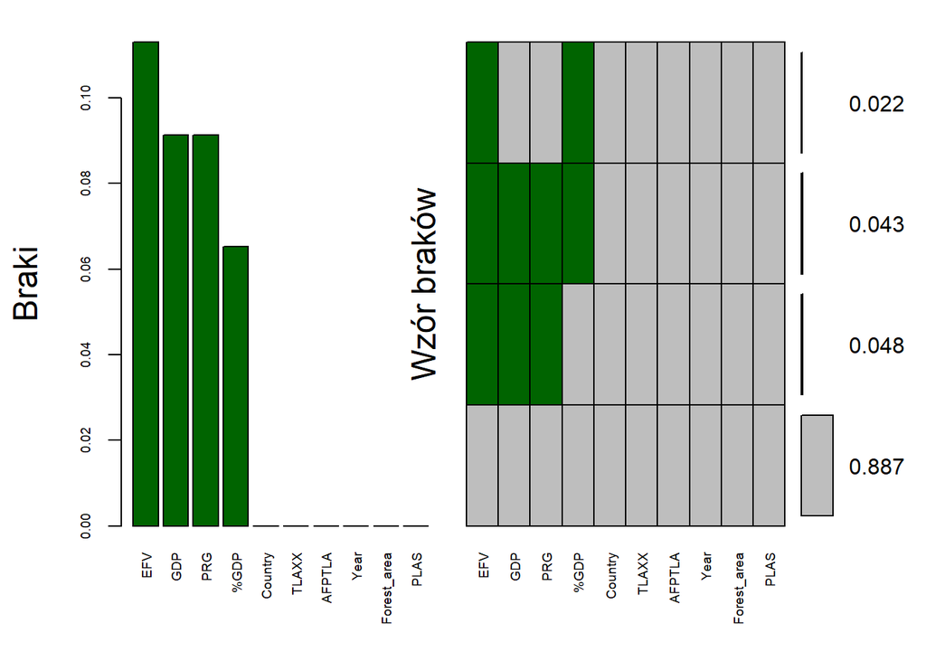

```
##
##  Variables sorted by number of missings:
##     Variable      Count
##          EFV 0.11304348
##          GDP 0.09130435
##          PRG 0.09130435
##         %GDP 0.06521739
##      Country 0.00000000
##        TLAXX 0.00000000
##       AFPTLA 0.00000000
##         Year 0.00000000
##  Forest_area 0.00000000
##         PLAS 0.00000000
```

```r
# aggr() - funkcja z pakietu VIM do wizualizacji braków danych
aggr(forest_gdp_db, col = c('grey', 'darkgreen'),
     numbers = TRUE, sortVars = TRUE,
     labels = names(forest_gdp_db), cex.axis = 0.6, cex.lab = 1.5,
     gap = 1, ylab = c('Braki', 'Wzór braków'))
```

# Badanie rozkładów zmiennych

## Badanie rozkładów normalnych

Nie badamy rozkładów zmiennych **Year** (Rok) i **Country** (Państwo), ponieważ mają ona tyle samo wartości dla każdego roku i każdego kraju.

Do badania pozostałych zmiennych użyjemy zdefiniowanej przez nas funkcji **normal_dstr_check**, która tworzy histogram, wykres kwantyl-kwantyl i wykonuje test Shapiro-Wilka dla wybranej zmiennej.

Powierzchnia lądowa (**TLAXX**)

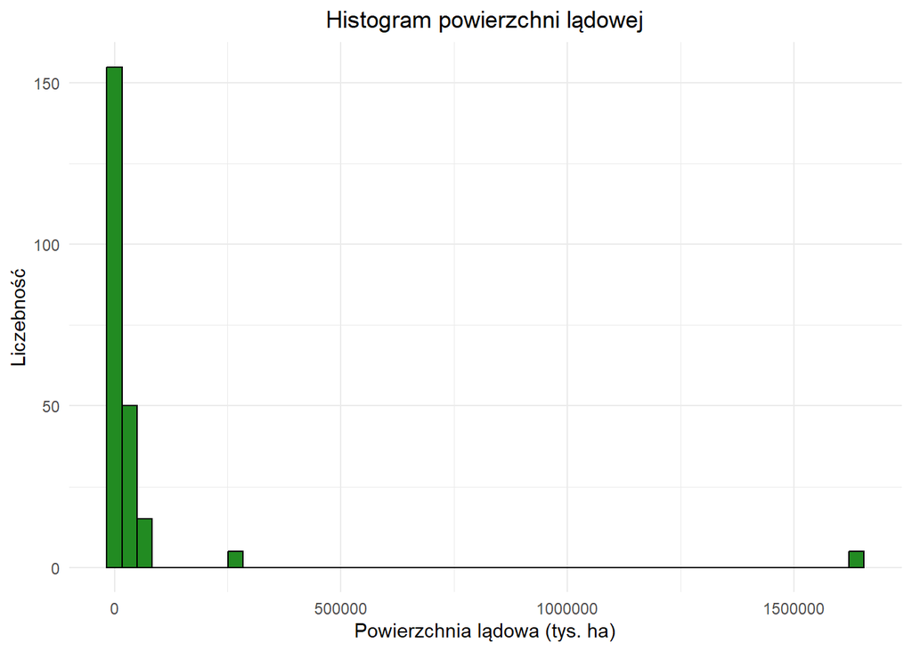

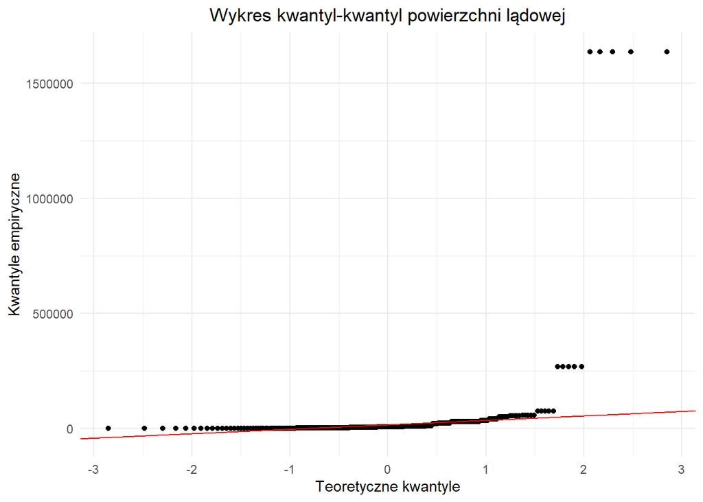

```
##
##  Shapiro-Wilk normality test
##
## data:  data
## W = 0.20287, p-value < 2.2e-16
```

```r
normal_dstr_check(forest_gdp_db, "TLAXX", bins = 50,
                  custom_title = "powierzchni lądowej",
                  custom_xlab = "Powierzchnia lądowa (tys. ha)")
```

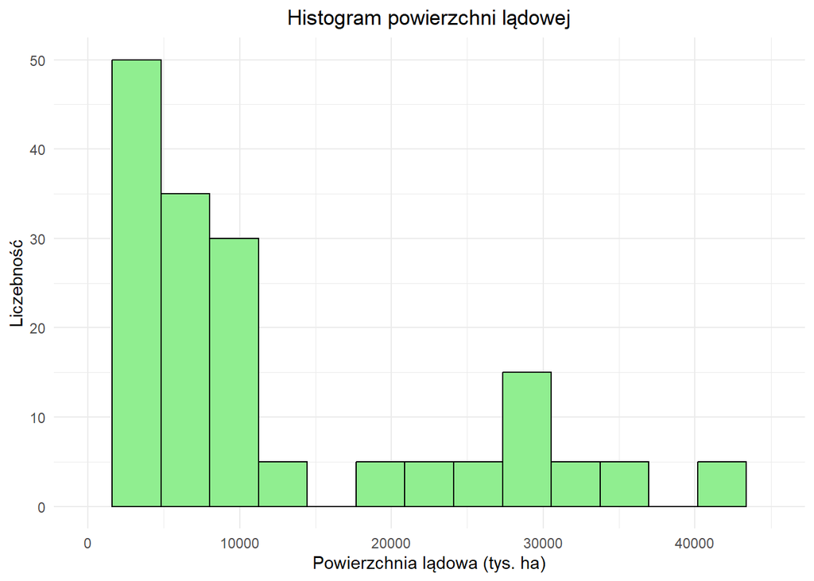

```r
ggplot(forest_gdp_db, aes(x = TLAXX)) +
  geom_histogram(
    bins = 15,
    fill = "lightgreen",
    color = "black",
    na.rm = TRUE
  ) +
  lims(x = c(0, 45000)) +
  labs(
    title = "Histogram powierzchni lądowej",
    x = "Powierzchnia lądowa (tys. ha)",
    y = "Liczebność"
  ) +
  theme_minimal() +
  theme(
    plot.title = element_text(hjust = 0.5)
  )
```

Na podstawie wykresów widzimy, że powierzchnia lądowa (**TLAXX**) nie ma rozkładu normalnego, rozkład jest prawoskośny. Dodatkowo w teście Shapiro-Wilka otrzymaliśmy wartość p < 0.05, zatem odrzucamy H0, czyli rozkład zmiennej opsiującej powierzchnię lądową (**TLAXX**) najprawdopodobniej nie jest normalny,

Procentowy udział powierzchni leśnej względem lądowej (**AFPTLA**)

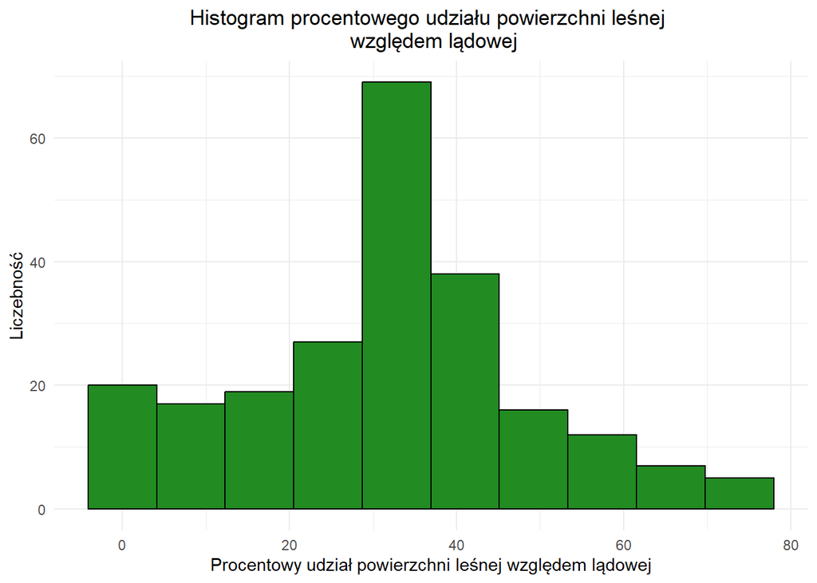

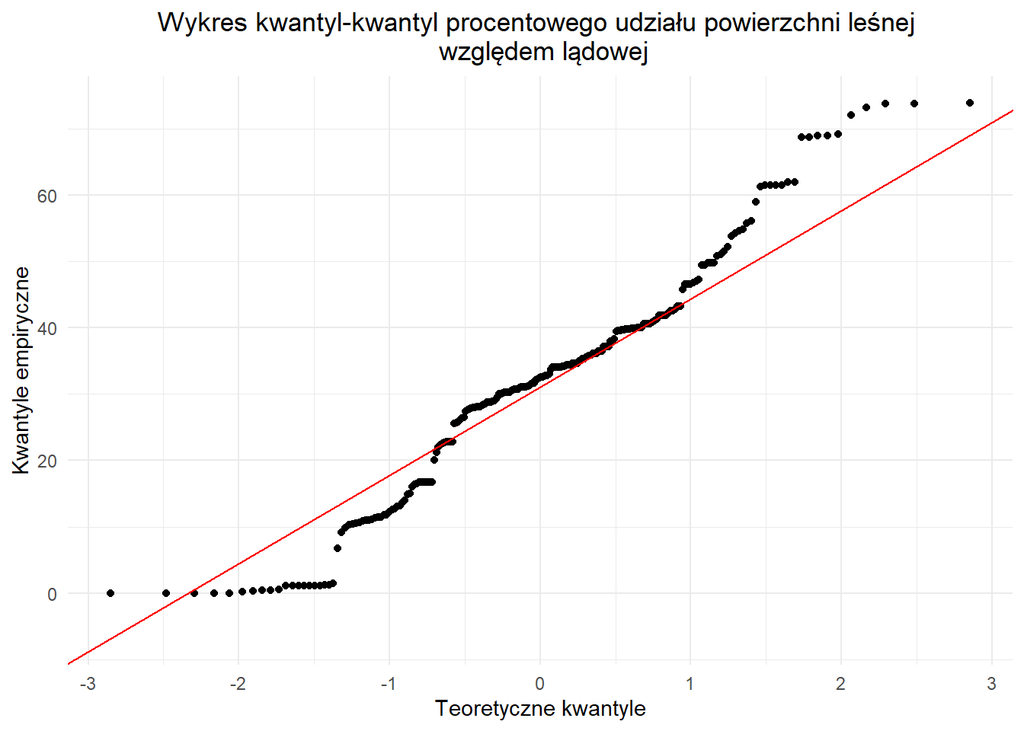

```
##
##  Shapiro-Wilk normality test
##
## data:  data
## W = 0.96815, p-value = 4.934e-05
```

```r
normal_dstr_check(forest_gdp_db, "AFPTLA", bins = 10,
                  custom_title = "procentowego udziału powierzchni leśnej \n względem lądowej",
                  custom_xlab = "Procentowy udział powierzchni leśnej względem lądowej")
```

Zauważamy, że histogram wygląda jak układ jednomodalny, czyli możliwe, że jest normalny. Na wykresie kwantyl-kwantyl widzimy, że może on być zbliżony do normalnego. W teście Shapiro-Wilka p wartość wyszła mniejsza niż 0.05, zatem odrzucamy H0, czyli zmienna opisująca procentowy udział powierzchni leśnej względem lądowej (**AFPTLA**) najprawdopodobniej nie ma rozkładu normalnego.

Powierzchnia leśna (**Foreast_area**)

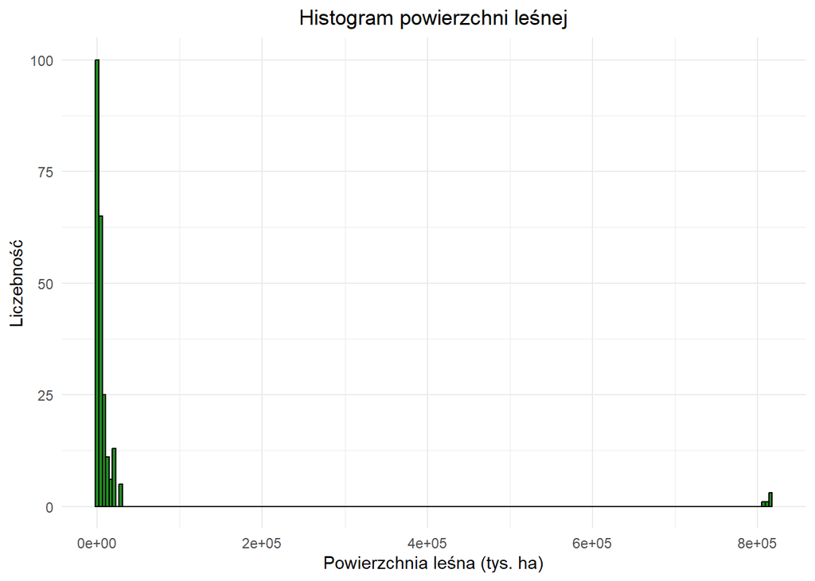

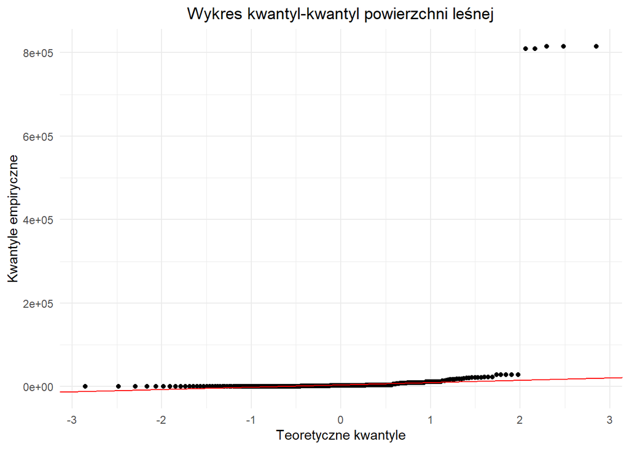

```
##
##  Shapiro-Wilk normality test
##
## data:  data
## W = 0.15954, p-value < 2.2e-16
```

```r
normal_dstr_check(forest_gdp_db, "Forest_area", bins = 200,
                  custom_title = "powierzchni leśnej",
                  custom_xlab = "Powierzchnia leśna (tys. ha)")
```

Histogram pokazuje, że w naszych danych związanych z powierzchnią lasów najprawdopodobniej występują obserwacje odstające, które znacznie utrudniają nam analizę innych danych. To samo widzimy na wykresie kwantyl-kwantyl, gdzie występuje ciężki prawy ogon. W teście Shapiro-Wilka wartość p wyszła mniejsza niż 0.05, zatem odrzucamy nasze H0, czyli zmienna opisująca powierzchnię lasów (**Forest_area**) najprawdopodobniej nie ma rozkładu normalnego. Tak jak wcześniej w przypadku zmiennej dotyczącej powierzni kraju, tworzymy kolejny histogram, w którym ograniczymy wartości na osi X, żeby wykluczyć obserwacje odstające.

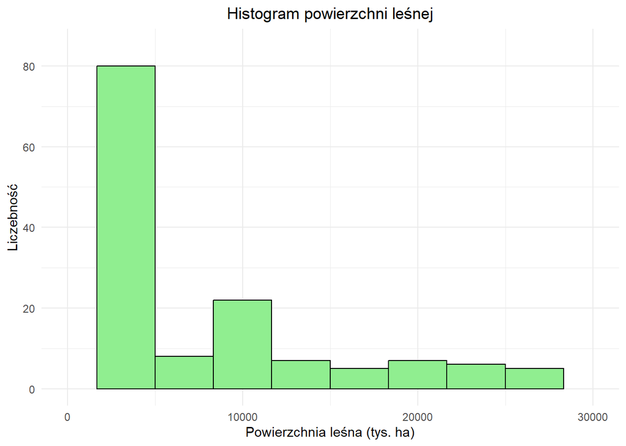

```r
ggplot(forest_gdp_db, aes(x = Forest_area)) +
  geom_histogram(
    bins = 10,
    fill = "lightgreen",
    color = "black",
    na.rm = TRUE
  ) +
  lims(x = c(0, 30000)) +
  labs(
    title = "Histogram powierzchni leśnej",
    x = "Powierzchnia leśna (tys. ha)",
    y = "Liczebność"
  ) +
  theme_minimal() +
  theme(
    plot.title = element_text(hjust = 0.5)
  )
```

Dane na histogramie pokazują rozkład prawoskośny. Widzimy, że dane najprawodpobniej nie mają rozkładu normalnego.

PKB (**GDP**)

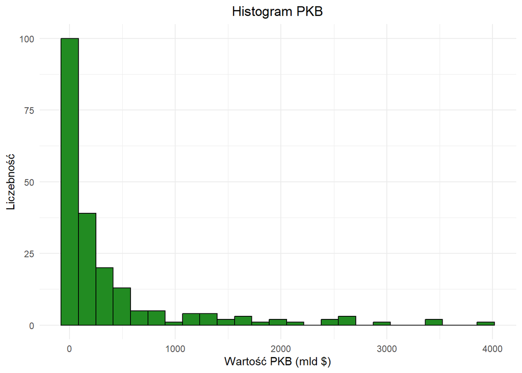

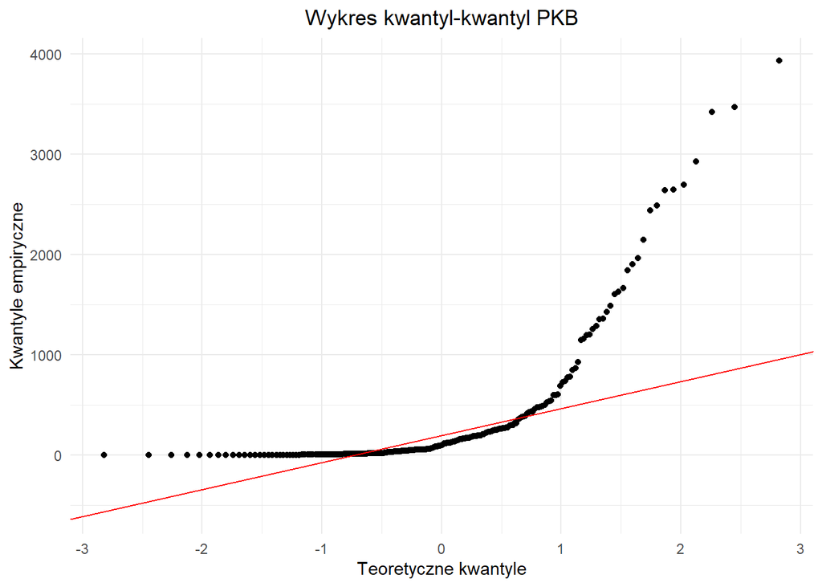

```
##
##  Shapiro-Wilk normality test
##
## data:  data
## W = 0.5936, p-value < 2.2e-16
```

```r
normal_dstr_check(forest_gdp_db, "GDP", bins = 25,
                  custom_title = "PKB",
                  custom_xlab = "Wartość PKB (mld $)")
```

Zauważamy na histogramie rozkład prawoskośny i potencjalne obserwacje odstające. Na wykresie kwantyl-kwantyl widzimy ciężki prawy ogon oraz lekki lewy. W teście Shapiro-Wilka p wartość wyszła mniejsza niż 0.05, zatem odrzucamy nasze H0, czyli zmienna opisująca PKB (**GDP**) najprawdopodobniej nie ma rozkładu normalnego. Tym razem również wykonamy kolejny histogram z ograniczoną osią X, aby wykluczyć potencjalne obserwacje odstające z wizualizacji.

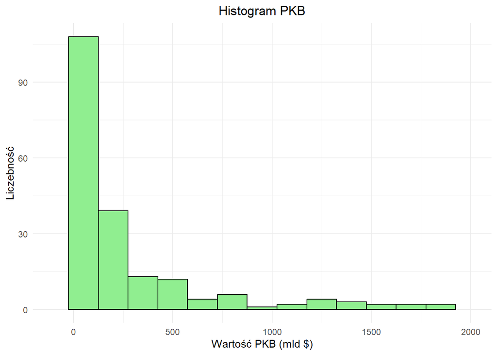

```r
ggplot(forest_gdp_db, aes(x = GDP)) +
  geom_histogram(
    bins = 15,
    fill = "lightgreen",
    color = "black",
    na.rm = TRUE
  ) +
  lims(x = c(-100, 2000)) +
  labs(
    title = "Histogram PKB",
    x = "Wartość PKB (mld $)",
    y = "Liczebność"
  ) +
  theme_minimal() +
  theme(
    plot.title = element_text(hjust = 0.5)
  )
```

Zauważamy rozkład prawoskośny, występuje dużo mniejszych wartości. Rozkład tej zmiennej najprawdopodobniej nie jest normalny.

Procentowy udział gospodarki leśnej w PKB (**%GDP**)

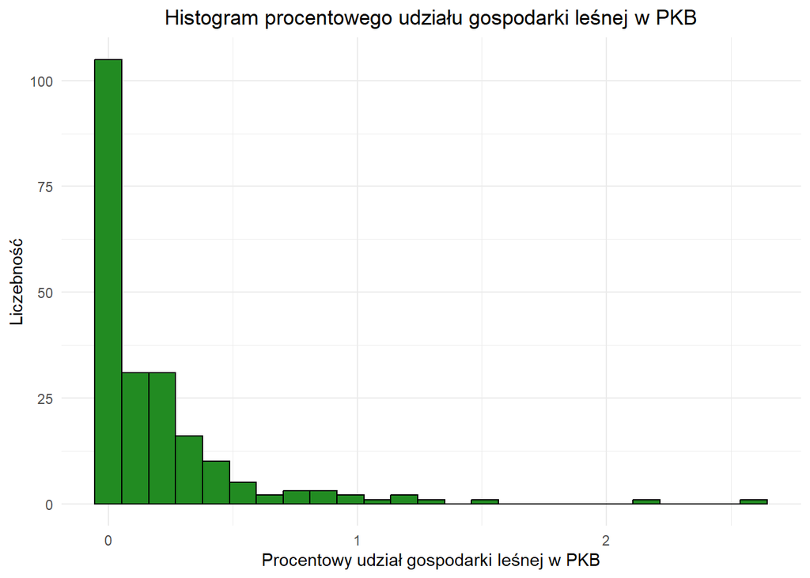

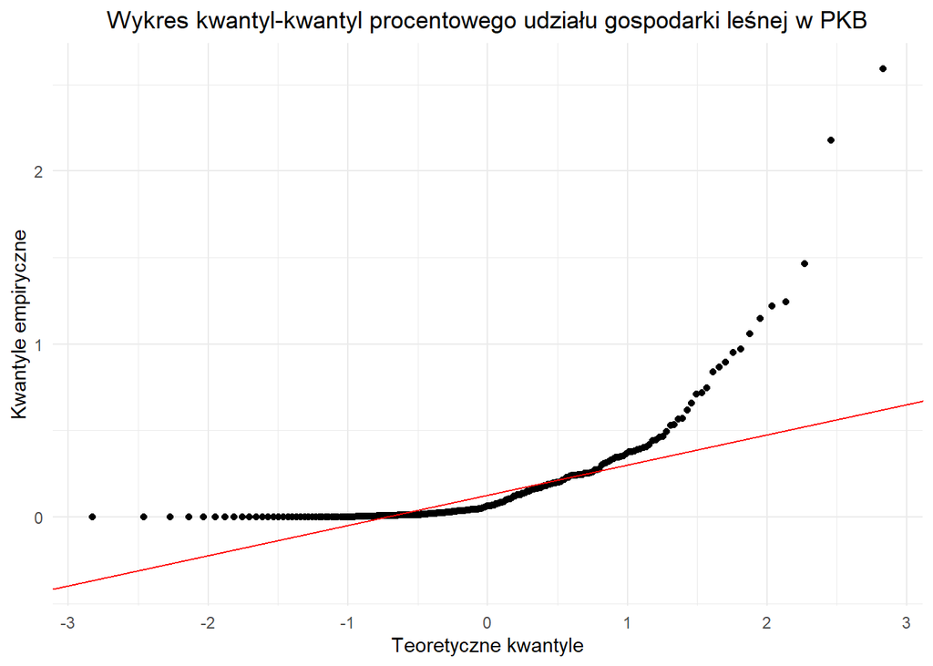

```
##
##  Shapiro-Wilk normality test
##
## data:  data
## W = 0.6, p-value < 2.2e-16
```

```r
normal_dstr_check(forest_gdp_db, "%GDP", bins = 25,
                  custom_title = "procentowego udziału gospodarki leśnej w PKB",
                  custom_xlab = "Procentowy udział gospodarki leśnej w PKB")
```

Tutaj podobna sytuacja jak w przypadku PKB (**GDP**), mianowicie zauważamy na histogramie rozkład prawoskośny i potencjalne obserwacje odstające. Na wykresie kwantyl-kwantyl widzimy ciężki prawy ogon i lekki lewy. W teście Shapiro-Wilka p wartość wyszła mniejsza niż 0.05, zatem odrzucamy nasze H0, czyli procentowy udział gospodarki leśnej w PKB (**%GDP**) najprawdopodobniej nie ma rozkładu normalnego. Jednak również wykonamy kolejny histogram ze zmniejszoną osią X, żeby upewnić się, że zmienna nie ma rozkładu normalnego.

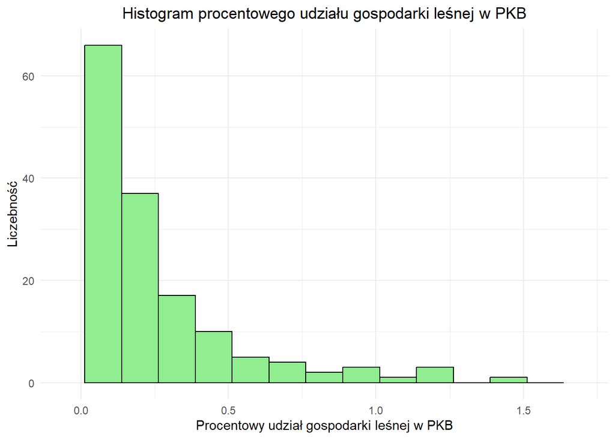

```r
ggplot(forest_gdp_db, aes(x = `%GDP`)) +
  geom_histogram(
    bins = 15,
    fill = "lightgreen",
    color = "black",
    na.rm = TRUE
  ) +
  lims(x = c(-0.05, 1.7)) +
  labs(
    title = "Histogram procentowego udziału gospodarki leśnej w PKB",
    x = "Procentowy udział gospodarki leśnej w PKB",
    y = "Liczebność"
  ) +
  theme_minimal() +
  theme(
    plot.title = element_text(hjust = 0.5)
  )
```

Po wykluczeniu obserwacji odstających, histogram dalej wykazuje rozkład prawoskośny, zatem zmienna najprawdopodobniej nie ma rozkładu normalnego.

Wartość gospodarki leśnej w PKB (**EFV**)

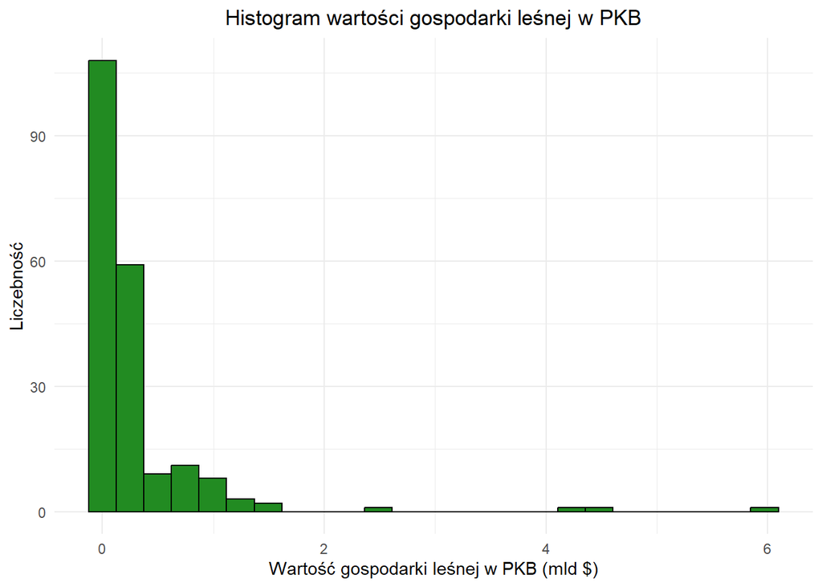

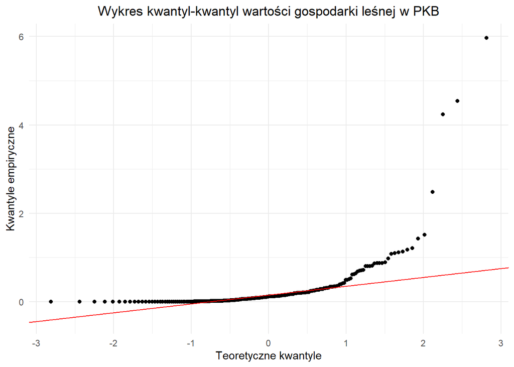

```
##
##  Shapiro-Wilk normality test
##
## data:  data
## W = 0.42415, p-value < 2.2e-16
```

```r
normal_dstr_check(forest_gdp_db, 'EFV', bins = 25,
                  custom_title = "wartości gospodarki leśnej w PKB",
                  custom_xlab = "Wartość gospodarki leśnej w PKB (mld $)")
```

Tutaj znowu podobna sytuacja jak w przypadku PKB (**GDP**), co jest logiczne, ponieważ wartość gospodarki leśnej w PKB (**EFV**) jest wyliczona na podstawie między innymi PKB (**GDP**). Zauważamy na histogramie rozkład prawoskośny i potencjalne obserwacje odstające. Na wykresie kwantyl-kwantyl widzimy ciężki prawy ogon. W teście Shapiro-Wilka p wartość wyszła mniejsza niż 0.05, zatem odrzucamy nasze H0, czyli zmienna opisująca wartość gospodarki leśnej w PKB (**EFV**) najprawdopodobniej nie ma rozkładu normalnego. Wykonamy również histogram z ograniczoną osią X, aby przeanalizować wykres bez potencjalnych obserwacji odstających.

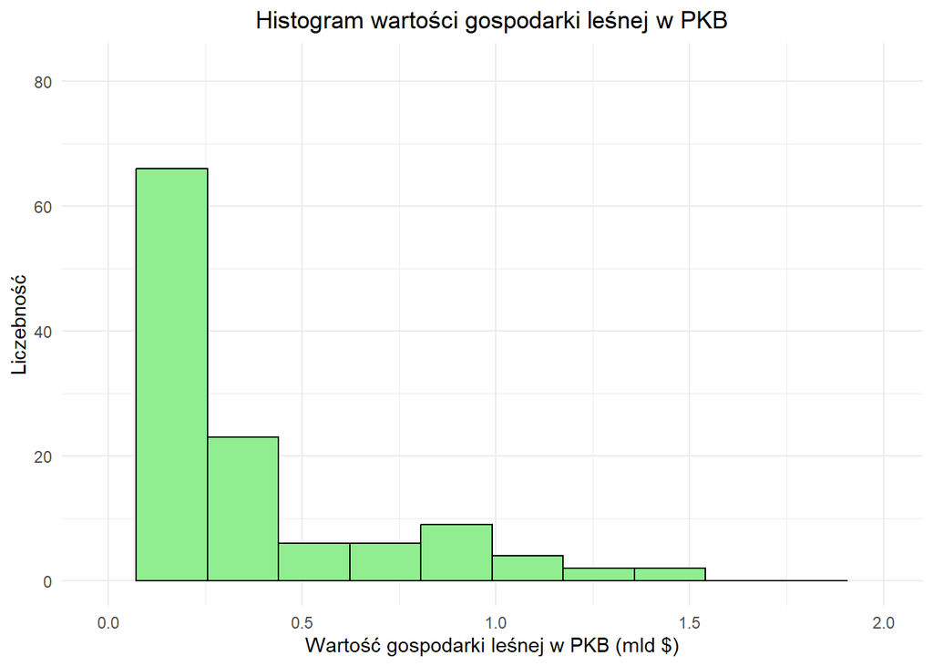

```r
ggplot(forest_gdp_db, aes(x = EFV)) +
  geom_histogram(
    bins = 12,
    fill = "lightgreen",
    color = "black",
    na.rm = TRUE
  ) +
  lims(x = c(-0.02, 2)) +
  labs(
    title = "Histogram wartości gospodarki leśnej w PKB",
    x = "Wartość gospodarki leśnej w PKB (mld $)",
    y = "Liczebność"
  ) +
  theme_minimal() +
  theme(
    plot.title = element_text(hjust = 0.5)
  )
```

Widzimy dalej rozkład prawoskośny, zatem zmienna opisująca wartość gospodarki leśnej w PKB (**EFV**) najprawdopodbniej nie ma rozkładu normalnego.

## Badanie rozkładów log-normalnych

Skoro nasze zmienne najprawodpodobniej nie mają rozkładu normalnego (zazwyczaj są prawostronnie skośne), sprawdzimy teraz czy może nie mają rozkładu log-normalnego za pomocą zdefiniowanej przez nas funkcji **normal_log_dstr_check**.

Powierzchnia lądowa po logarytmizacji (log**TLAXX**)

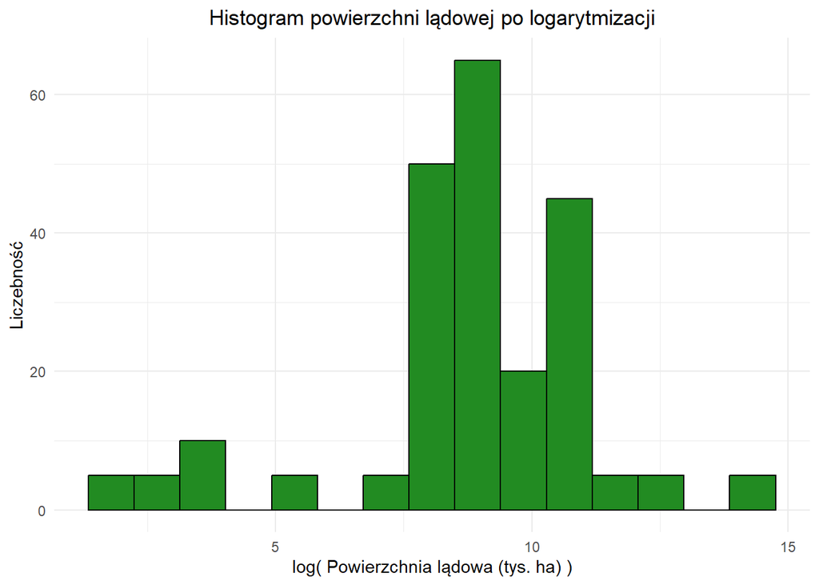

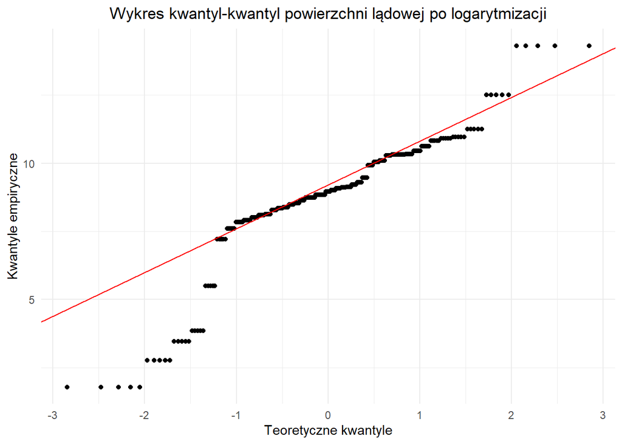

```
##
##  Shapiro-Wilk normality test
##
## data:  log_data
## W = 0.88088, p-value = 2.636e-12
```

```r
normal_log_dstr_check(forest_gdp_db, "TLAXX", bins = 15,
                      custom_title = "powierzchni lądowej",
                      custom_xlab = "Powierzchnia lądowa (tys. ha)")
```

Histogram powierzchni lądowej (**TLAXX**) po logarytmizacji wygląda znacznie lepiej, jednak na wykresie kwantyl-kwantyl dalej zauważamy ciężki lewy i prawy ogon, a w teście Shapiro-Wilka dostajemy p wartość mniejszą niż 0.05, zatem odrzucamy H0, czyli zmienna opisująca powierzchnię lądową po logarytmizacji (log**TLAXX**) najprawdopodobniej dalej nie ma rozkładu normalnego.

Procentowy udział powierzchni leśnej względem lądowej po logarytmizacji (log**AFPTLA**)

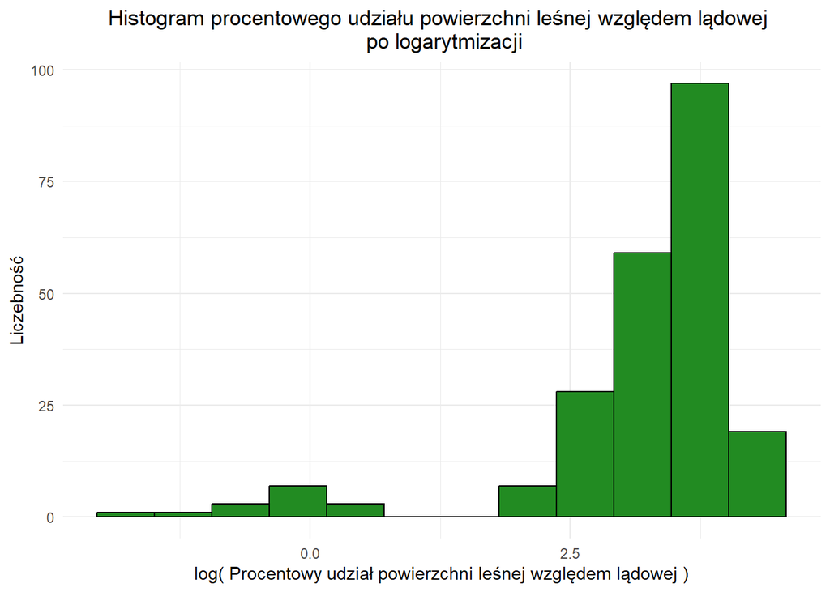

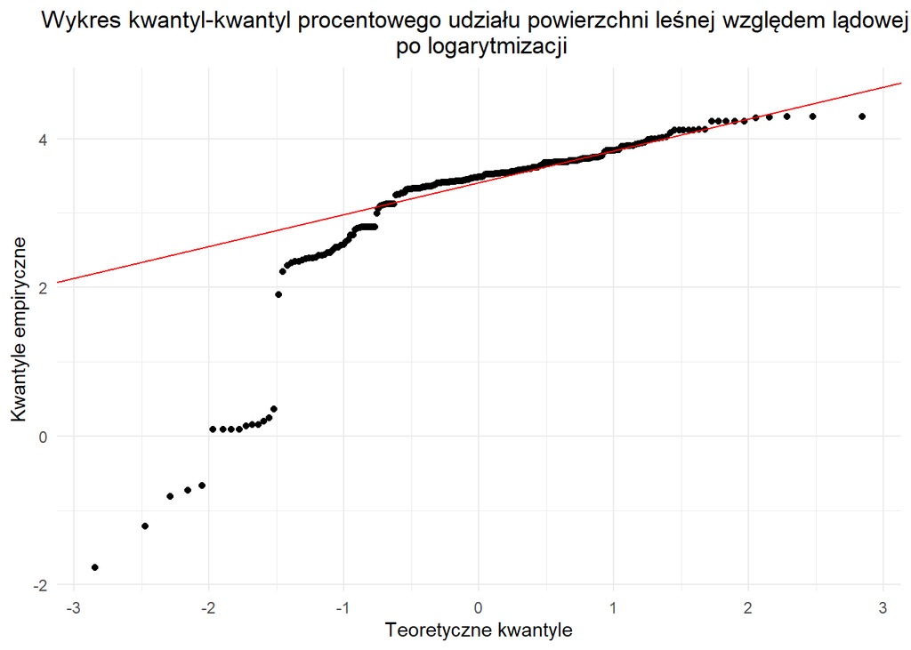

```
##
##  Shapiro-Wilk normality test
##
## data:  log_data
## W = 0.69116, p-value < 2.2e-16
```

```r
normal_log_dstr_check(forest_gdp_db, "AFPTLA", bins = 12,
                      custom_title = "procentowego udziału powierzchni leśnej względem lądowej \n",
                      custom_xlab = "Procentowy udział powierzchni leśnej względem lądowej")
```

Na histogramie zauważamy tym razem rozkład lewoskośny, wykres kwantyl-kwantyl pokazuje ciężki lewy ogon, a z testu Shapiro-Wilka dostajemy p wartość mniejsza niż 0.05, zatem odrzucamy H0, czyli zmienna opisująca procentowy udział powierzchni leśnej względem lądowej po logarytmizacji (log**AFPTLA**) najprawdopodobniej nie ma rozkładu normalnego.

Powierzchnia leśna po logarytmizacji (log**Forest_area**)

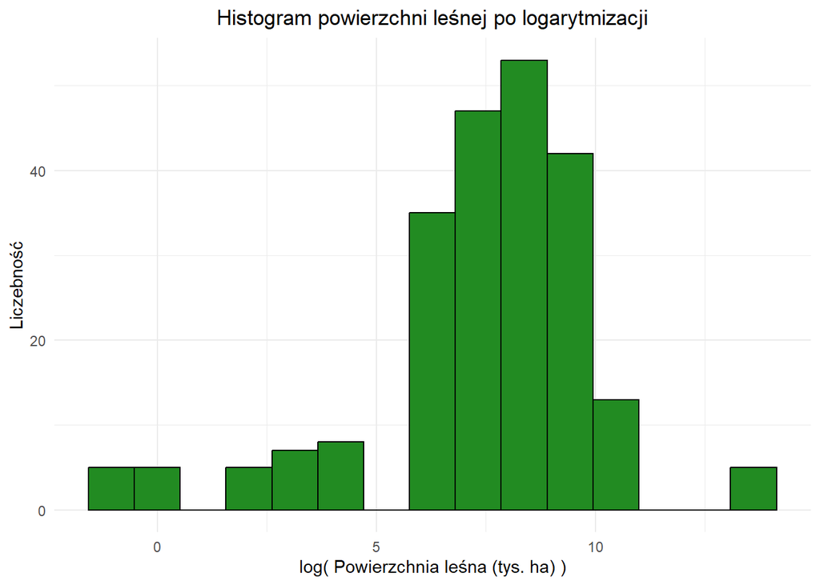

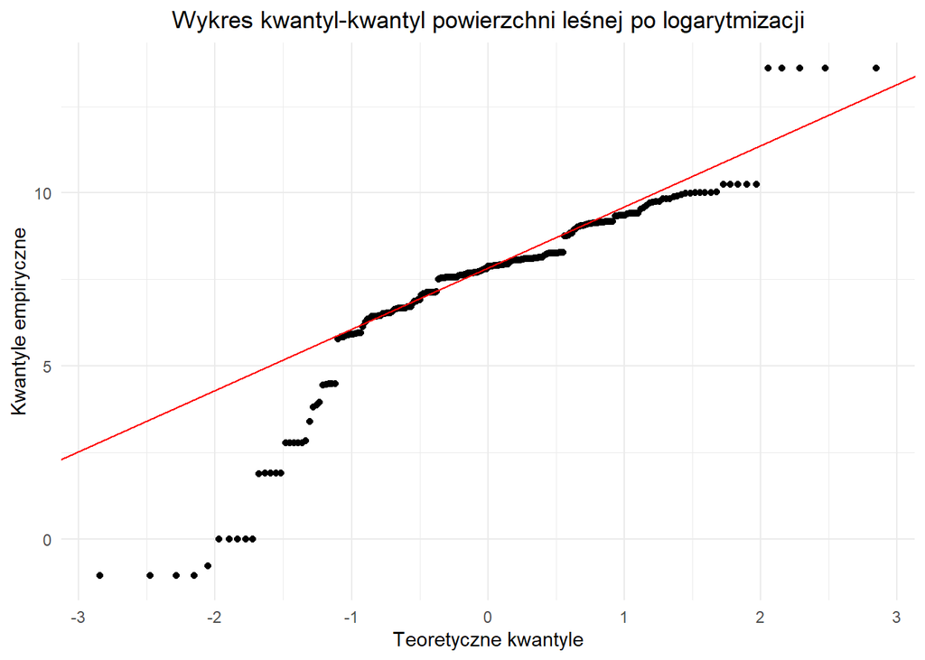

```
##
##  Shapiro-Wilk normality test
##
## data:  log_data
## W = 0.87003, p-value = 6.239e-13
```

```r
normal_log_dstr_check(forest_gdp_db, "Forest_area", bins = 15,
                      custom_title = "powierzchni leśnej",
                      custom_xlab = "Powierzchnia leśna (tys. ha)")
```

Na histogramie zauważamy dużo wartości w centrum wykresu i niewiele wartości po bokach. Z wykresu kwantyl-kwantyl widzimy, że występuje ciężki lewy ogon, a w teście Shapiro-Wilka otrzymujemy p wartość mniejszą niż 0.05, zatem odrzucamy H0, czyli zmienna opisująca powierzchnię lądową po logarytmizacji (log**Forest_area**) najprawdopodobniej nie ma rozkładu normalnego.

PKB po logarytmizacji (log**GDP**)

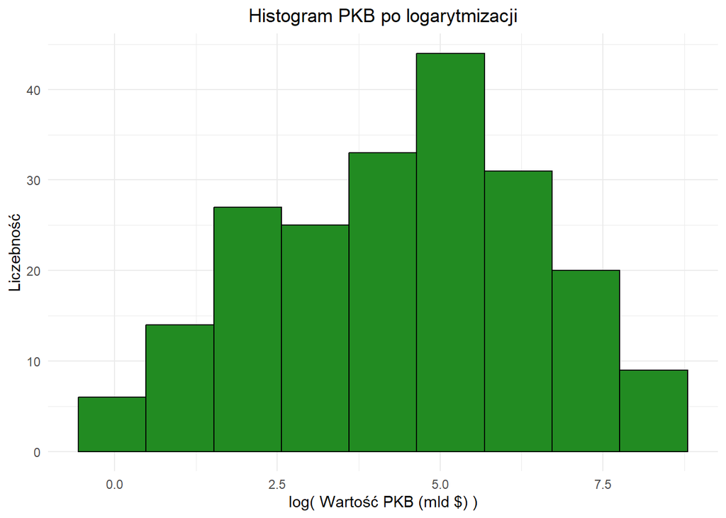

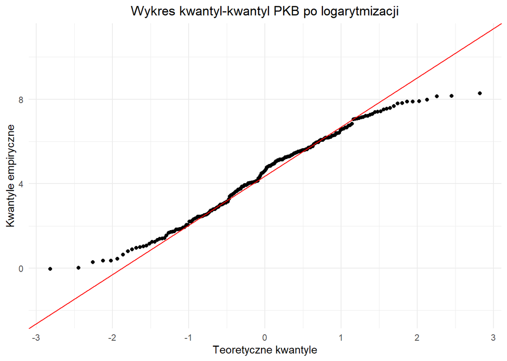

```
##
##  Shapiro-Wilk normality test
##
## data:  log_data
## W = 0.97823, p-value = 0.002519
```

```r
normal_log_dstr_check(forest_gdp_db,"GDP", bins = 9,
                      custom_title = "PKB",
                      custom_xlab = "Wartość PKB (mld $)")
```

Dla PKB po logarytmizacji (log**GDP**) otrzymaliśmy histogram, który wyglądem może przypominać rozkład normalny. Dodatkowo na wykresie kwantyl-kwantyl zauważamy, że tylko niektóre wartości odstają od czerwonej linii, szczególnie w lewym ogonie. Jednak z testu Shapiro-Wilka wciąż otrzymujemy p wartość mniejszą niż 0.05, zatem odrzucamy H0, czyli zmienna opsiująca PKB po logarytmizacji (log**GDP**) najprawdopodobniej dalej nie ma rozkładu normalnego.

Procentowy udział gospodarki leśnej w PKB po logarytmizacji (log**%GDP**)

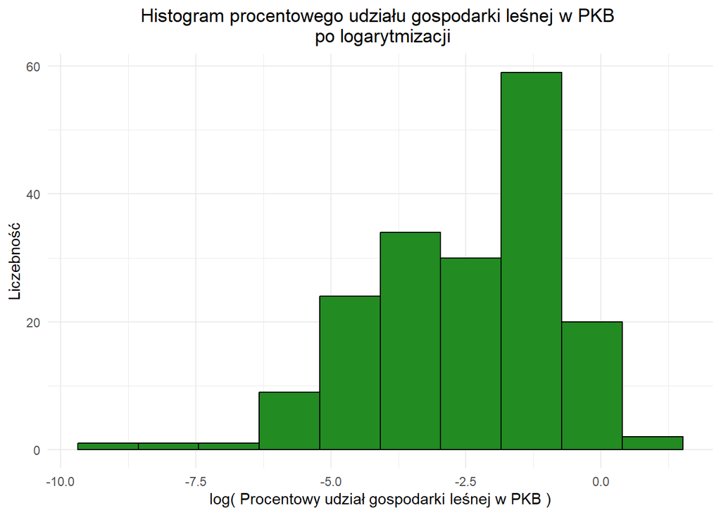

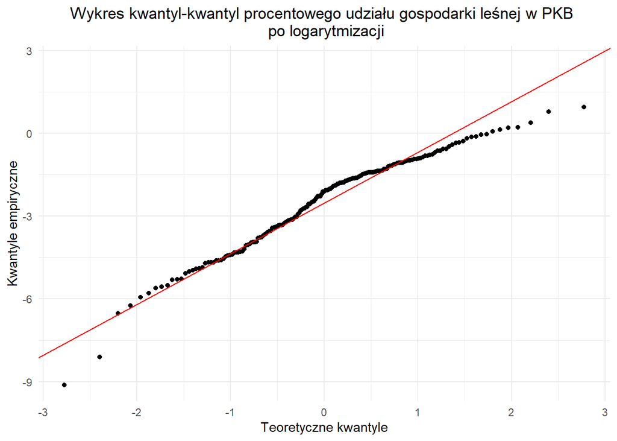

```
##
##  Shapiro-Wilk normality test
##
## data:  log_data
## W = 0.96496, p-value = 0.0001668
```

```r
normal_log_dstr_check(forest_gdp_db, "%GDP", bins = 10,
                      custom_title = "procentowego udziału gospodarki leśnej w PKB \n",
                      custom_xlab = "Procentowy udział gospodarki leśnej w PKB")
```

Bardzo podobną sytuację mamy dla procentowego udział gospodarki leśnej w PKB po logarytmizacji (log**%GDP**), jednak i w tym przypadku w teście Shapiro-Wilka otrzymujemy p wartość mniejszą niż 0.05, zatem odrzucamy H0, czyli zmienna opisująca procentowy udział gospodarki leśnej w PKB po logarytmizacji (log**%GDP**) najprawdopodobniej dalej nie ma rozkładu normalnego.

Wartość gospodarki leśnej w PKB po logarytmizacji (log**EFV**)

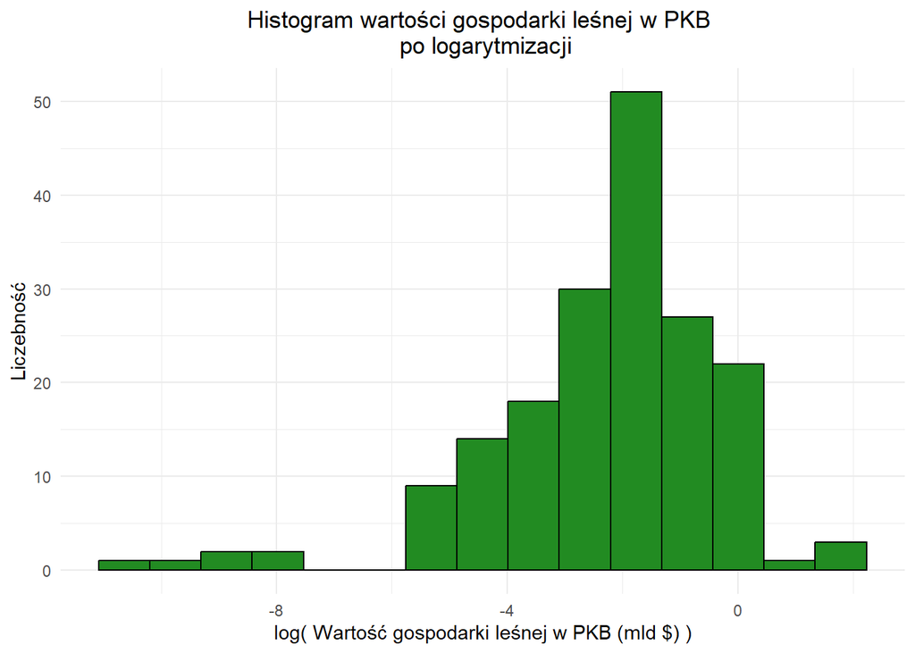

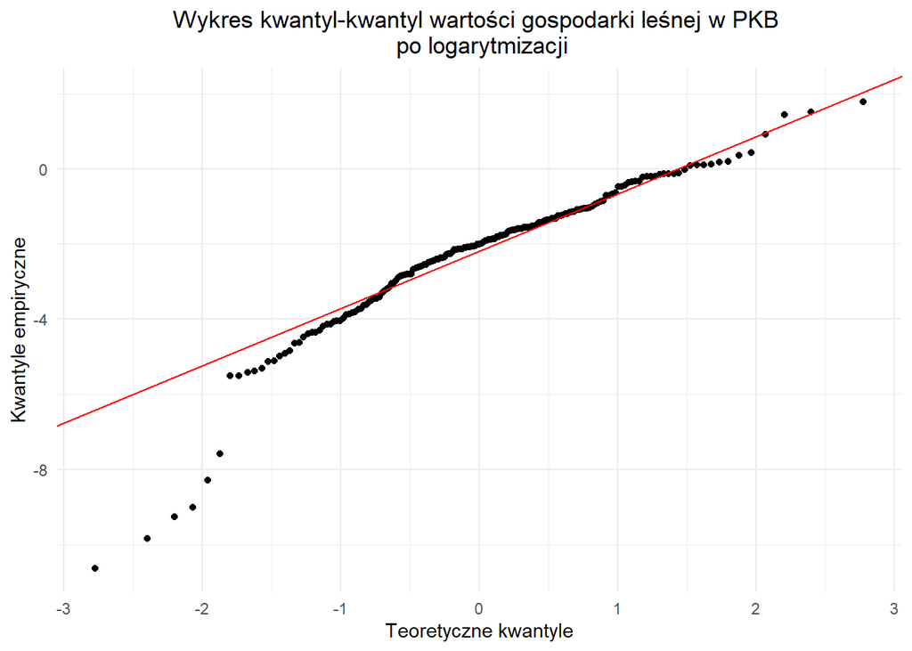

```
##
##  Shapiro-Wilk normality test
##
## data:  log_data
## W = 0.90866, p-value = 3.715e-09
```

```r
normal_log_dstr_check(forest_gdp_db, "EFV", bins = 15,
                      custom_title = "wartości gospodarki leśnej w PKB \n",
                      custom_xlab = "Wartość gospodarki leśnej w PKB (mld $)")
```

W przypadku wartości gospodarki leśnej w PKB po logarytmizacji (log**EFV**) na histogramie zauważamy rozkład lewoskośny, a na wykresie kwantyl-kwantyl widzimy ciężki lewy ogon. W teście Shapiro-Wilka otrzymaliśmy p wartość mniejszą niż 0.05, zatem odrzucamy H0, czyli zmienna opisująca wartość gospodarki leśnej w PKB po logarytmizacji (log**EFV**) najprawdopodobniej dalej nie ma rozkładu normalnego.

Podsumowując, mimo wykonania logarytmizacji naszych zmiennych, żadna z nich najprawdopodobniej nie posiada rozkładu normalnego. Logarytmowanie zmniejszyło rozrzut danych i spłaszczyło ogony rozkładów, ale nie doprowadziło do normalności. Można więc rozważyć dalsze przekształcenia lub stosowanie metod statystycznych niewymagających normalności.

# Badanie zależności między zmiennymi

## Analiza graficzna korelacji

Za pomocą heatmapy, gdzie kolory i wielkość kół wskazują zarówno kierunek, jak i siłę zależności oraz analizy macierzy wykresów par zmiennych (ggpairs) sprawdzimy czy nasze zmienne ilościowe mogą w jakimś stopniu od siebie zależeć.

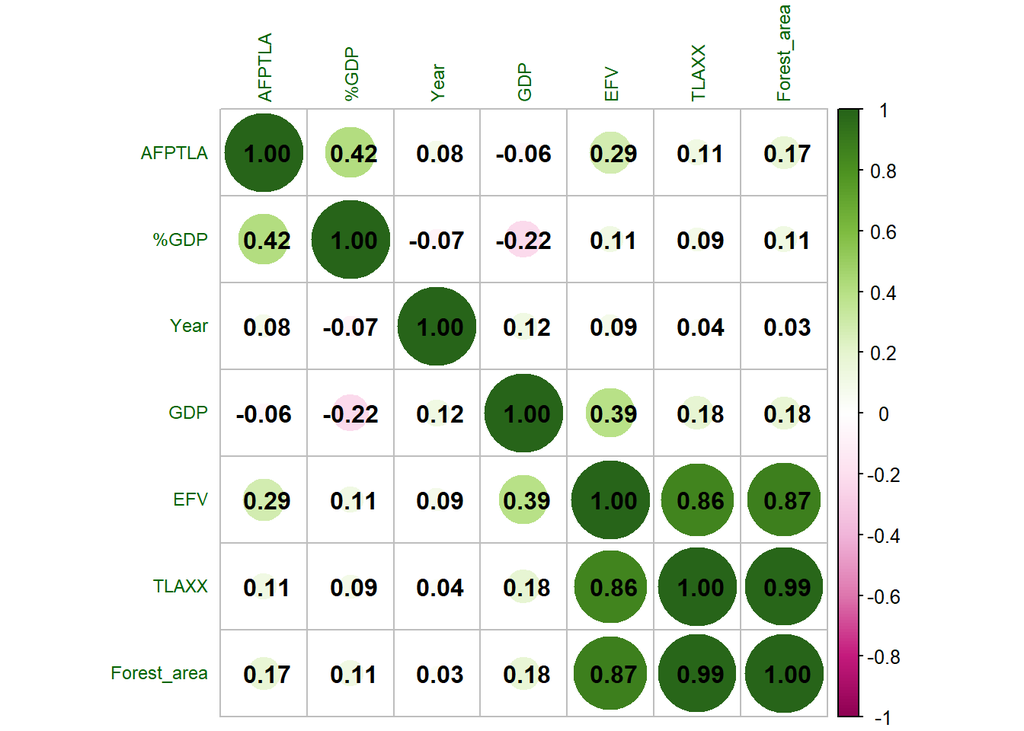

```r
# select_if() filtruje kolumny spełniające warunek is.numeric
num_vars <- select_if(forest_gdp_db, is.numeric)

# cor() wyznacza współczynniki korelacji Pearsona
# use = "complete.obs" oznacza, że do obliczeń używane są tylko obserwacje bez braków danych
cor_matrix <- cor(num_vars, use = "complete.obs")

# corrplot() tworzy graficzną reprezentację zależności między zmiennymi
corrplot::corrplot(
  cor_matrix,
  order = "hclust",            # porządkowanie zmiennych na podstawie hierarchicznej analizy skupień
  addCoef.col = "black",       # dodanie wartości współczynników korelacji w kolorze czarnym
  col = corrplot::COL2("PiYG"),# paleta kolorów
  tl.cex = 0.75,               # rozmiar czcionki etykiet zmiennych
  tl.col = "darkgreen"         # kolor etykiet zmiennych
)
```

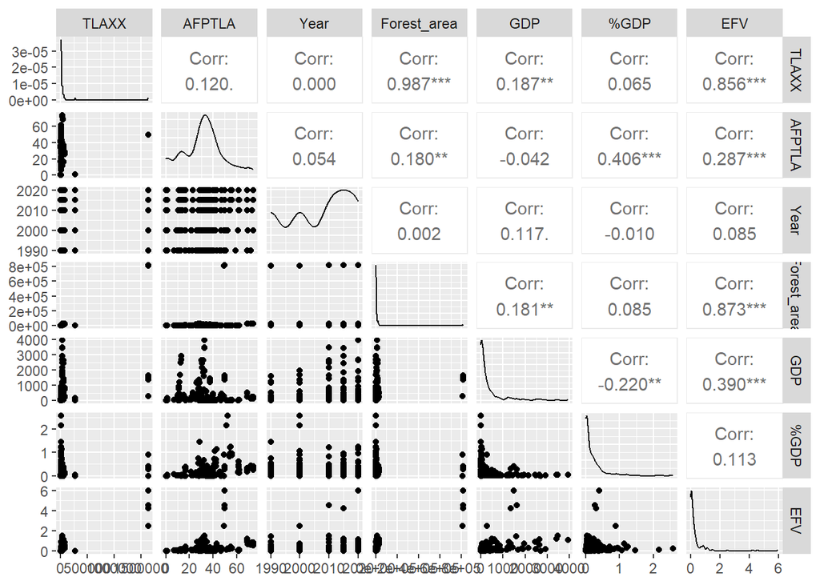

```r
# operator |> przekazuje wynik do kolejnej funkcji
# ggpairs() (pakiet GGally) tworzy macierz wykresów:
# - na przekątnej: rozkłady pojedynczych zmiennych
# - poza przekątną: wykresy rozrzutu dla par zmiennych
# - dodatkowo: współczynniki korelacji między zmiennymi
ggpairs(forest_gdp_db |> select(-Country, -PRG, -PLAS))
```

Istotne korelacje: (-) - oznacza, że współczynnik korelacji jest ujemny

**Silne korelacje (> 0.5):**

*Forest_area* -> *TLAXX*

*EFV* -> *TLAXX*

*EFV* -> *Forest_area*

Korelacje między tymi zmiennymi przekraczają 0.85, co sugeruje, że rosną one razem. Może to wskazywać, że państwa o większej powierzchni lasów jednocześnie generują wyższe wartości gospodarcze powiązane z sektorem leśnym.

**Umiarkowane korelacje (0.25 - 0.5):**

*%GDP* -> *AFPTLA*

*EFV* -> *AFPTLA*

*EFV* -> *GDP*

Procentowy udział powierzchni leśnej względem lądowej (**AFPTLA**) i procentowy udział gospodarki leśnej w PKB (**%GDP**) są umiarkowanie skorelowane. Może to oznaczać, że kraje z większą powierzchnią lasów mają również większy udział sektora leśnego w PKB. Korelacje między wartością gospodarki leśnej w PKB (**EFV**) a PKB (**GDP**) są dodatnie, ale umiarkowane, co sugeruje, że wydajność gospodarcza związana z lasami wzrasta wraz z ogólnym poziomem PKB, choć nie jest to zależność bardzo silna.

**Słabe korelacje (< 0.25):**

*%GDP* -> *GDP* (-)

*GDP* -> *TLAXX*

*Forest_area* -> *AFPTLA*

*GDP* -> *Forest_area*

Uzyskane wartości współczynników korelacji wskazują na słabe związki liniowe pomiędzy analizowanymi zmiennymi. Oznacza to, że zmiany jednej zmiennej nie są w istotnym stopniu powiązane ze zmianami drugiej, a ewentualne zależności mają charakter marginalny. Rok (**Year**) nie koreluje z innymi zmiennymi. To oznacza brak wyraźnych trendów czasowych w całym zbiorze.

## Test ANOVA

Państwa (**Country**)

```r
anova_results <- anova_table(forest_gdp_db, "Country")
print(anova_results)
```

```
##   categorical_var numeric_var       p_value significant
## 1         Country       TLAXX  0.000000e+00        TRUE
## 2         Country      AFPTLA 2.862989e-167        TRUE
## 3         Country        Year  1.000000e+00       FALSE
## 4         Country Forest_area  0.000000e+00        TRUE
## 5         Country         GDP  8.357099e-54        TRUE
## 6         Country        %GDP  2.686783e-28        TRUE
## 7         Country         EFV  3.488284e-62        TRUE
```

Z wyników testu ANOVA dla zmiennej zawierającej nazwy państw (**Country**) zauważamy, że większość analizowanych zmiennych ilościowych różni się istotnie między krajami europejskimi. Wszystkie zmienne oprócz Roku (**Year**) uzyskały bardzo niską p wartość, co oznacza, że ich średnie wartości są zależne od kraju. Wskazuje to na duże zróżnicowanie między państwami w zakresie gospodarki leśnej oraz powiązanych wskaźników ekonomicznych. Jedyną zmienną, która nie wykazała różnic między krajami, jest Rok (**Year**) (p wartość = 1.00), co jest zgodne z naszymi oczekiwaniami, ponieważ wszystkie państwa posiadają te same lata pomiarowe. Ogólnie wyniki potwierdzają, że dane są silnie zróżnicowane, a analiza porównawcza między krajami jest uzasadniona i statystycznie istotna.

Poziom rozwoju gospodarczego (**PRG**)

```r
anova_results <- anova_table(forest_gdp_db, "PRG")
print(anova_results)
```

```
##   categorical_var numeric_var      p_value significant
## 1             PRG       TLAXX 2.407466e-02        TRUE
## 2             PRG      AFPTLA 7.982089e-02       FALSE
## 3             PRG        Year 2.717579e-01       FALSE
## 4             PRG Forest_area 3.653677e-02        TRUE
## 5             PRG         GDP 1.344467e-37        TRUE
## 6             PRG        %GDP 1.055366e-05        TRUE
## 7             PRG         EFV 2.375173e-07        TRUE
```

Poziom lesistości (**PLAS**)

```r
anova_results <- anova_table(forest_gdp_db, "PLAS")
print(anova_results)
```

```
##   categorical_var numeric_var      p_value significant
## 1            PLAS       TLAXX 5.112125e-03        TRUE
## 2            PLAS      AFPTLA 7.673619e-93        TRUE
## 3            PLAS        Year 6.979554e-01       FALSE
## 4            PLAS Forest_area 8.765493e-04        TRUE
## 5            PLAS         GDP 6.210857e-02       FALSE
## 6            PLAS        %GDP 9.754300e-12        TRUE
## 7            PLAS         EFV 3.120442e-04        TRUE
```

Test ANOVA przeprowadzony dla zmiennej jakościowej opisującej poziom lesistości (**PLAS**) pokazał, że większość analizowanych zmiennych ilościowych różni się istotnie między poziomami tej kategorii. Oznacza to, że poziomy lesistości (**PLAS**) są powiązane z wyraźnymi różnicami zarówno w zasobach leśnych, jak i w ekonomicznych aspektach gospodarki leśnej. Brak istotnych zależności dotyczy zmiennej rok (**Year**) oraz PKB (**GDP**), dla których p wartość jest wyższa niż 0.05. Sugeruje to, że poziomy lesistości (**PLAS**) nie wpływają na rozkład lat występowania danych oraz poziom PKB. Ogólnie wyniki wskazują, że poziom lesistości (**PLAS**) różnicuje przede wszystkim zmienne związane z intensywnością i wartością gospodarki leśnej, natomiast nie ma znaczącego związku z dynamiką czasową.

## Test Chi-kwadrat

Za pomocą testu Chi-kwadrat sprawdzimy wzajemną zależność między zmiennymi jakościowymi.

```r
cat_vars <- c("Country", "PRG", "PLAS") # Lista zmiennych jakościowych

alpha <- 0.05 # Poziom istotności

# Tworzymy pustą ramkę
results <- data.frame(
  var1 = character(),
  var2 = character(),
  p_value = numeric(),
  significant = logical(),
  stringsAsFactors = FALSE
)

# Iteracja
for (i in 1:(length(cat_vars)-1)) {
  for (j in (i+1):length(cat_vars)) {

    # usuwamy NA
    tmp <- forest_gdp_db[, c(cat_vars[i], cat_vars[j])]
    tmp <- tmp[complete.cases(tmp), ]

    # Tworzymy tabelę przestawną
    tbl <- table(tmp[[1]], tmp[[2]])

    # Test chi-kwadrat (symulacja p-value jeśli małe liczebności)
    test <- chisq.test(tbl, simulate.p.value = TRUE)

    # Dodanie wyniku
    results <- rbind(results, data.frame(
      var1 = cat_vars[i],
      var2 = cat_vars[j],
      p_value = test$p.value,
      significant = test$p.value < alpha
    ))
  }
}

results
```

```
##      var1 var2      p_value significant
## 1 Country  PRG 0.0004997501        TRUE
## 2 Country PLAS 0.0004997501        TRUE
## 3     PRG PLAS 0.0029985007        TRUE
```

Test Chi-kwadrat we wszystkich trzech porównaniach uzyskał bardzo niskie p wartości, co oznacza, że zależności są statystycznie istotne. Oznacza to, że rozkłady zmiennych opisujących poziom rozwoju gospodarczego (**PRG**) oraz poziom lesistości (**PLAS**) różnią się pomiędzy krajami, a także że same te zmienne nie są od siebie niezależne. Innymi słowy, poziomy tych zmiennych współwystępują w sposób nieprzypadkowy: kraj, w którym znajduje się dany obserwowany poziom rozwoju gospodarczego (**PRG**), ma również większe prawdopodobieństwo określonego poziomu lesistości (**PLAS**), i odwrotnie. Wyniki te wskazują, że zmienne jakościowe opisujące charakterystykę gospodarowania zasobami leśnymi nie są niezależne ani od siebie, ani od kraju.

## Współczynnik V Cramera i Spearmana

Współczynnik V Cramera mierzy siłę zależności między dwiema zmiennymi jakościowymi, gdzie wartość 0 oznacza brak zależności, a 1 - pełną zależność. Współczynnik Spearmana mierzy korelację między dwiema zmiennymi porządkowymi, gdzie wartość -1 oznacza pełną ujemną korelację, a 1 - pełną dodatnią korelację. Dla zmiennych jakościowych użyjemy współczynnika V Cramera, a dodatkowo dla zmiennych o skali porządkowej wykonamy test korelacji rang Spearmana.

Państwo (**Country**) i Poziom rozwoju gospodarczego (**PRG**)

```r
# wybór dwóch zmiennych
tmp <- forest_gdp_db[, c("Country", "PRG")]

# usuwanie NA
tmp <- tmp[complete.cases(tmp), ]

# tabela częstości
tbl <- table(tmp$Country, tmp$PRG)

# Cramer V
cramers_v <- cramerV(tbl, bias.correct = TRUE)
cat("V Cramer dla Państwa i Poziomu rozwoju gospodarczego: ", cramers_v[1], "\n")
```

```
## V Cramer dla Państwa i Poziomu rozwoju gospodarczego:  0.6737
```

Wartość współczynnika V Cramera = 0.6737 jest wysoka, co sugeruje, że między poziomem rozwoju gospodarczego (**PRG**) a krajem (**Country**) jest silna zależność.

Państwo (**Country**) i Poziom lesistości (**PLAS**)

```r
# wybór dwóch zmiennych
tmp <- forest_gdp_db[, c("Country", "PLAS")]

# usuwanie NA
tmp <- tmp[complete.cases(tmp), ]

# tabela częstości
tbl <- table(tmp$Country, tmp$PLAS)

# Cramer V
cramers_v <- cramerV(tbl, bias.correct = TRUE)
cat("V Cramer dla Państwa i Poziomu lesistości: ", cramers_v[1], "\n")
```

```
## V Cramer dla Państwa i Poziomu lesistości:  0.8372
```

Wartość współczynnika V Cramera = 0.8372 jest wysoka, co sugeruje, że między poziomem lesistości (**PLAS**) a krajem (**Country**) jest silna zależność.

Poziom lesistości (**PLAS**) i poziom rozwoju gospodarczego (**PRG**)

```r
# wybór dwóch zmiennych
tmp <- forest_gdp_db[, c("PLAS", "PRG")]

# usuwanie NA
tmp <- tmp[complete.cases(tmp), ]

# tabela częstości
tbl <- table(tmp$PLAS, tmp$PRG)

# Cramer V
cramers_v <- cramerV(tbl, bias.correct = TRUE)

# Spearman (dla porządkowych)
# trzeba zamienić kategorie na liczby
spearman_corr <- cor(
  as.numeric(tmp$PLAS),
  as.numeric(tmp$PRG),
  method = "spearman"
)

cat("V Cramer dla Poziomu lesistości i rozwoju gospodarczego: ", cramers_v[1], "\n")
```

```
## V Cramer dla Poziomu lesistości i rozwoju gospodarczego:  0.1588
```

```r
cat("Spearman dla Poziomu lesistości i rozwoju gospodarczego: ", spearman_corr)
```

```
## Spearman dla Poziomu lesistości i rozwoju gospodarczego:  -0.05332428
```

Wartość współczynnika V Cramera = 0.1588 jest niska, co sugeruje, że związek między poziomem lesistości (**PLAS**) a poziomem rozwoju gospodarczego (**PRG**) jest słaby.

Wynik współczynnika Spearmana = -0.0533 oznacza, że praktycznie nie ma liniowego ani monotonicznego związku między poziomem lesistości a poziomem rozwoju gospodarczego.

Na podstawie tych danych poziom lesistości kraju jest słabo powiązany z jego poziomem rozwoju gospodarczego.